# Vignette for package *rehh*

Alexander Klassmann, Renaud Vitalis and Mathieu Gautier

2021-09-15

# 1 About the package

This vignette describes comprehensively how the R package *rehh* can be applied to perform whole genome scans for footprints of selection using statistics related to *Extended Haplotype Homozygosity (EHH)* (Sabeti *et al.* 2002). The vignette *Examples in detail* explains basic usage and methodology with the help of two tiny artificial data sets.

The package accepts multi-allelic genetic markers as input. Typically, albeit not necessarily, these will be bi-allelic SNPs.

The package is available for Linux, Windows and MacOS X from the CRAN repository https://cran.r-project.org/package=rehh and may be installed using a standard procedure. Once the package has been successfully installed, it can be loaded by:

```r
library(rehh)
```

## 1.1 Background

The analysis of molecular population genetic data often comprises the search for genomic regions that might have experienced recent selection. Diverse approaches have been developed; for reviews on methodology see (Sabeti 2006), (Oleksyk *et al.* 2010) and (Vitti *et al.* 2013) and for practical advice (Cadzow *et al.* 2014), (Utsunomiya *et al.* 2015) and (Weigand and Leese 2018). However only a few have found wide-spread application (Haasl and Payseur 2016). To the latter belong *iHS* (Voight *et al.* 2006), *Rsb* (Tang *et al.* 2007) and *XP-EHH* (Sabeti *et al.* 2007), all of which are *summary statistics* aimed to distill a certain aspect of the genetic data into a single score and constructed in a way that extreme values are indicative of positive or “Darwinian” selection. *iHS* is intended for application on a single (presumably homogeneous) population, while *XP-EHH* and *Rsb* are targeted to differential selection between two populations. All three statistics are based on the concept of *Extended Haplotype Homozygosity (EHH)* as formulated by (Sabeti *et al.* 2002).

*iHS* and *XP-EHH* can be calculated by the independent C++ command line tool *Hapbin* (Maclean *et al.* 2015), which has been optimized for speed by exploiting bit-wise machine-level operations. The package *rehh* cannot compete on performance, but has the advantage of being able to work with multi-allelic markers and missing values. Moreover, it possesses a broader range of input and output options, including several graphical representations.

## 1.2 Changes between versions 2.X and 3.X

Due to changes in the API, although mostly small, the versions 3.X are not compatible with versions 2.X.

Data objects of class `haplohh` (see below) created by versions up to 2.0.4 must be updated via the command `update_haplohh()` (see its documentation by typing `?update_haplohh`) in order to be accepted by the functions of the current version.

## 1.3 Example files

For illustration purposes, several example input files as well as R objects are provided.

### 1.3.1 Input files

- Two tiny invented examples, each in our “standard” haplotype format (see section 2) and in *variant call format* (*vcf*). The first example was used in (Gautier *et al.* 2017) for the explanation of the various statistics calculated by this package. The second example is an extension of the former including multi-allelic markers and missing values. Both sets are discussed in depth in a second vignette.
- Further three tiny examples used for the supplement on Site Frequency Spectrum-based methods of (Klassmann and Gautier 2020).
- An output file of the program *ms* containing two small simulated haplotype samples.
- A data set in various formats that originated from a study on the “Creole cattle breed from Guadeloupe” (CGU) (Gautier and Naves 2011). All files contain the same set of phased SNPs of *Bos taurus* chromosome 12 from 140 individuals.

All of the above files are copied into the current working directory via the command

```r
make.example.files()
```

**Throughout the vignette, this command is assumed to have been run!**

### 1.3.2 R objects

- The data set for chromosome 12 of the cattle study mentioned above as object of the *rehh* data class `haplohh`. This object becomes available by the command `data(haplohh_cgu_bta12)`.
- The scores *iHH* and *iES* as obtained by the function `scan_hh()` applied on SNPs of the whole genome for the population CGU (defined above) and another population EUT (“European taurine”). They reside in the accompanying package `rehh.data` and are obtained by `library(rehh.data)` followed by `data(wgscan.cgu)` resp. `data(wgscan.eut)`.

## 1.4 Terminology

Depending on the context, we refer as *chromosomes* either to the different chromosomes of a species’ reference sequence (e.g. “chr1”, “chr2”, “chrX”, etc.) or to the homologous chromosomes from different individuals (e.g. 280 times “chr12” from 140 diploid individuals). The sequence of alleles on a chromosome is referred to as its *haplotype* and sometimes we use it interchangeably with *chromosome*. However, if we speak of a *shared haplotype*, the term is meant more abstractly for the unique sequence of alleles that a group of chromosomes share at each position within a certain region.

## 1.5 Overview

The package calculates three statistics which can be used to perform whole-genome scans for selection: *iHS*, *XP-EHH* and *Rsb*. *iHS* compares alleles within a single population while the other two compare sites between populations. The calculation proceeds technically in five steps which are performed by running two commands and combining tables:

- each marker is taken in turn as a “focal marker” around which the extended haplotype homozygosity is computed at further markers in increasing distance to the focal marker up to some stop criterion
- for each focal marker these quantities are “integrated” over the surrounding markers
- these integrals have to be calculated for each chromosome separately and the resulting tables to be combined to yields whole-genome statistics
- at each focal position, two such integrals are compared (either from two alleles or from two populations) by taking their log ratio
- the distribution of these log-ratios is standardized

Here is a minimal code example for calculating *iHS* on a single chromosome:

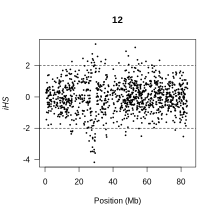

```r
hh <-                  # data input
  data2haplohh(
    hap_file = "bta12_cgu.hap",
    map_file = "map.inp",
    chr.name = "12",
    allele_coding = "map"
  )
scan <- scan_hh(hh)    # calculation of EHH and integration
                       # (combine results from different chromosomes)
ihs <- ihh2ihs(scan)   # log ratio for alleles and standardization
manhattanplot(ihs)     # plot of the statistics
```

# 2 Data input

The package *rehh* requires as input:

- a haplotype data file (see section 2.1).

and, if the haplotype data file is neither in *variant call format* nor in the format of *ms* output,

- a marker information file (see section 2.2).

Since R can automatically recognize and read compressed files with standard name extensions like *.gz* or *.bzip2*, this holds as well for the input files that can be used with this package.

## 2.1 Haplotype data file

Five haplotype input file formats are supported:

- a *standard* haplotype format. Each row represents a haplotype with marker genotype in columns as in the example file `bta12_cgu.hap` containing 280 haplotypes with 1424 SNPs each (see section 2.3.1). The first element of each row is taken as a haplotype identifier.
- a *transposed* format with haplotypes in columns and markers in rows as in the example file `bta12_cgu.thap`. This format is similar to the one produced by the phasing program *SHAPEIT2* (O’Connell *et al.* 2014). This format assumes neither row nor column names and hence no haplotype identifiers can be specified (see section 2.3.2).
- the output file format from the phasing program *fastPHASE* (Scheet and Stephens 2006) as in the `bta12_hapguess_switch.out` example file. Note that this file format allows to include haplotypes from several populations (if the -u *fastPHASE* option was used) (see section 2.3.3).
- *variant call format (vcf)*, comprising both haplotype and marker information. In order to read files in this format, the package vcfR or the packages data.table and R.utils (the latter is needed for compressed files) have to be installed (see section 2.3.4).
- The output of the simulation program *ms* (Hudson 2002) and its derivatives *msHOT* (Hellenthal and Stephens 2007), *ms<sup>2</sup>* (Ewing and Hermisson 2010) and *ms’* (Kelleher *et al.* 2016). In order to read these files, the package gap has to be installed (see section 2.3.5).

Alleles in standard or transposed haplotype format can be provided either coded (by integer numbers) or without coding (e.g. as nucleotides) (see section 2.3).

If alleles are not polarized, i.e. their ancestral/derived status is not known, some arbitrary assignation can be done either beforehand by the user or during input by the package; appropriate parameters must be set in subsequent functions (see section 7.6).

## 2.2 Marker information file

For haplotype data files in standard, transposed or fastphase format a marker information file has to be provided. The file should contain columns without header corresponding to:

1. marker name/identifier
2. name of the chromosome (or scaffold)
3. position on the chromosome (or scaffold), either physical (in bases) or genetic (e.g. in centiMorgans).

**For a given chromosome, the markers must be ordered in the same way as in the haplotype data file.**

If alleles in the haplotype file are not already provided in coded form (i.e. as positive integers), the package can (re)code them using two additional columns in the marker file:

4. ancestral allele
5. derived allele(s).

For instance, the provided file `map.inp` has five columns:

```r
# show first 6 lines of file
cat(readLines("map.inp", n = 6), sep = "\n")
```

```
> F0100190 1 113642 T A
> F0100220 1 244699 C G
> F0100250 1 369419 G C
> F0100270 1 447278 A T
> F0100280 1 487654 T A
> F0100290 1 524507 C G
```

## 2.3 Loading data files: the function `data2haplohh`

The `data2haplohh()` function converts data files into an R object of class `haplohh`, forming the basis for subsequent analysis. The following options are available to recode alleles and/or to filter markers and haplotypes:

**1. Allele coding options**:

The parameter `allele_coding` has four options: three of them expect the user to provide a coding, while the fourth option overwrites any user defined coding.

The package accepts two different integer codings within the haplotype file which can be specified as `"12"` or `"01"`, respectively:

|  | “12” | “01” |
| --- | --- | --- |
| Missing value | 0 | `NA` or . |
| Ancestral allele | 1 | 0 |
| Derived allele 1 | 2 | 1 |
| Derived allele 2 | 3 | 2 |
| … | … | … |

The latter one is also the coding used internally by our package.

If the alleles are given in an un-coded form (e.g. as nucleotides), the alleles can be coded for each marker separately with help of the marker information file. This option is activated by `allele_coding = "map"`. If an allele of a marker is found in the fourth column of the marker information file, it is re-coded as 0 (ancestral) and if it is found in the fifth column it is re-coded as 1 (derived). The fifth column may contain several alleles, separated by commas, like in the *variant call format*. In this case, the internal coding extends to higher integers. If an allele present in the haplotype file is not found neither in the fourth nor the fifth column of the marker information file, it is counted as `NA` (missing value).

If the alleles are not polarized, i.e. it is unknown which allele is ancestral and which derived, the option `"none"` should be selected. The alleles will then be coded in alpha-numeric order for each marker; the first becomes 0, the second 1, etc. Missing values must be given as `NA` or ‘.’ while any other number, character or string will be counted as an allele. Options of subsequent analysis functions have to be set accordingly (see section 7.6).

**2. Filtering options**

2.1 **Discard haplotypes with a high amount of missing data**. If haplotypes contain missing data (presumably a rare case since most phasing programs allow imputing missing genotypes), it is possible to discard those with a fraction of less than `min_perc_geno.hap` of markers genotyped. Its default is `NA`, hence no restriction.

2.2. **Discard markers with a high amount of missing data**. It is possible to discard individual markers genotyped on a fraction of less than `min_perc_geno.mrk` of haplotypes. By default `min_perc_geno.mrk = 100` meaning that only fully genotyped markers are retained. A value of `NA` or zero is not allowed since *rehh* cannot handle markers with no data.

2.3 **Discard markers with a low Minor Allele Frequency**. It is possible to discard markers with a Minor Allele Frequency (MAF) equal to or below `min_maf`. Its default is `NA` meaning no constraint. Setting this value to zero eliminates monomorphic markers. Note that since low-frequency alleles usually abound, any positive value may exclude a substantial fraction of the data.

The arguments `min_perc_geno.hap`, `min_perc_geno.mrk` and `min_maf` are evaluated in this order.

More details about input options can be found in the documentation using the command:

```r
?data2haplohh
```

### 2.3.1 Example 1: reading haplotype file in standard format

The following command converts the haplotype input file `bta12_cgu.hap` (in “standard” haplotype format) and marker information input file `map.inp` to an `haplohh` object named `hh`. Because the map file contains information for markers mapping to multiple chromosomes we have to specify by `chr.name = 12` that the haplotype input file is about chromosome 12. Alleles are given as nucleotides in the haplotype file and coded with help of the map file by setting `allele_coding = "map"`.

```r
hh <- data2haplohh(hap_file = "bta12_cgu.hap",
                   map_file = "map.inp",
                   chr.name = 12,
                   allele_coding = "map")
```

```
> * Reading input file(s) *
> Map info: 1424 markers declared for chromosome 12 .
> Haplotype input file in standard format assumed.
> Alleles are being recoded according to fourth and fifth column of map file.
> * Filtering data *
> Discard markers genotyped on less than 100 % of haplotypes.
> No marker discarded.
> Data consists of 280 haplotypes and 1424 markers.
> Number of mono-, bi-, multi-allelic markers:
> 1 2
> 27 1397
```

If no value is specified for `chr.name` and more than one chromosome is detected in the map file, an error is produced:

```r
hh <- data2haplohh(hap_file = "bta12_cgu.hap",
                   map_file = "map.inp",
                   allele_coding = "map")
```

```
> * Reading input file(s) *
> More than one chromosome name in file: map.inp .
> Here is a list of chromosome names found:
>  1 2 3 4 5 6 7 8 9 10 11 12 13 14 15 16 17 18 19 20 21 22 23 24 25 26 27 28 29
```

```
> Error: Please specify a chromosome name. Conversion stopped.
```

Furthermore, the following message is prompted if the number of markers for the chromosome in the info file does not correspond to the one in the haplotype file (for instance when a wrong chromosome is specified):

```r
hh <- data2haplohh(hap_file = "bta12_cgu.hap",
                   map_file = "map.inp",
                   chr.name = 18,
                   allele_coding = "map")
```

```
> * Reading input file(s) *
> Map info: 1123 markers declared for chromosome 18 .
> Haplotype input file in standard format assumed.
```

```
> Error: The number of markers in the haplotype file (1424) is not equal
> to the number of markers in the map file (1123).
> Conversion stopped.
```

### 2.3.2 Example 2: reading haplotype file in transposed format (*SHAPEIT2*–like)

If the haplotype input file is in “transposed” format (like `bta12_cgu.thap`), the option `haplotype.in.columns` has to be set to `TRUE` while all other parameters remain unaffected with respect to example 1. This is the only format which is not recognized automatically, but has to be explicitly declared by the user.

```r
hh <- data2haplohh(hap_file = "bta12_cgu.thap",
                   map_file = "map.inp",
                   chr.name = 12,
                   allele_coding = "map",
                   haplotype.in.columns = TRUE)
```

```
> * Reading input file(s) *
> Map info: 1424 markers declared for chromosome 12 .
> Haplotype input file in transposed format assumed.
> Alleles are being recoded according to fourth and fifth column of map file.
> * Filtering data *
> Discard markers genotyped on less than 100 % of haplotypes.
> No marker discarded.
> Data consists of 280 haplotypes and 1424 markers.
> Number of mono-, bi-, multi-allelic markers:
> 1 2
> 27 1397
```

### 2.3.3 Example 3: reading haplotype file in *fastPHASE* output format

In this example, we use the *fastPHASE* output `bta12_hapguess_switch.out` as haplotype file. This format is recognized automatically. As before, we need to set `chr.name = 12`. Because haplotypes originated here from several populations (the *fastPHASE* option `-u` was used), it is necessary to select the population of interest (in our case “CGU”) by its corresponding number in the file, hence `popsel = 7`.

```r
hh <- data2haplohh(hap_file = "bta12_hapguess_switch.out",
                   map_file = "map.inp",
                   chr.name = 12,
                   popsel = 7,
                   allele_coding = "map")
```

```
> * Reading input file(s) *
> Map info: 1424 markers declared for chromosome 12 .
> Haplotype input file in fastPHASE format assumed.
> Haplotypes in the fastPHASE output file originate from 8 populations.
> Alleles are being recoded according to fourth and fifth column of map file.
> * Filtering data *
> Discard markers genotyped on less than 100 % of haplotypes.
> No marker discarded.
> Data consists of 280 haplotypes and 1424 markers.
> Number of mono-, bi-, multi-allelic markers:
> 1 2
> 27 1397
```

If no value is specified for the `popsel` argument and more than one population is detected in the *fastPHASE* output file, an error is produced and the available population numbers printed:

```r
hh <- data2haplohh(hap_file = "bta12_hapguess_switch.out",
                   map_file = "map.inp",
                   chr.name = 12,
                   allele_coding = "map")
```

```
> * Reading input file(s) *
> Map info: 1424 markers declared for chromosome 12 .
> Haplotype input file in fastPHASE format assumed.
> Haplotypes in the fastPHASE output file originate from 8 populations.
```

```
> Error: Please specify by 'popsel' one of the following population numbers:
> 1 2 3 4 5 6 7 8
> Conversion stopped.
```

### 2.3.4 Example 4: reading vcf files

The function `data2haplohh()` checks automatically whether the specified haplotype input file is in *variant call format (vcf)*. If this is the case, the parameters `map_file` and `allele_coding` are ignored. By default, the function tries to polarize (see section 7.6) the alleles of each marker using the ancestral allele, expected to be given by key `AA` of the `INFO` field.

Ancestral alleles are sometimes marked by upper case as “high confident” and by lower case as “low confident”. The default setting `capitalize_AA = TRUE` lifts this distinction before polarization.

If the `AA` key is absent, the option `polarize_vcf` should be set to `FALSE` and the allele coding of the *vcf* file is directly used as internal coding.

If there is data for more than one chromosome in the file, the chromosome of interest has to be specified by `chr.name`. Since always the whole file is read in, it is advisable to split large data sets into chromosome-specific files.

In order to process *vcf* files, the package vcfR or the package data.table (which in turn needs R.utils to read compressed files) have to be installed. The parameter `vcf_reader` has to be set to either `"vcfR"` or `"data.table"`.

In the file `bta12_cgu.vcf.gz` the ancestral allele was set as reference and hence no further polarizing is necessary.

```r
hh <- data2haplohh(hap_file = "bta12_cgu.vcf.gz",
                   polarize_vcf = FALSE,
                   vcf_reader = "data.table")
```

```
> * Reading input file(s) *
> Using package 'data.table' to read vcf.
> Extracting map information.
> Extracting haplotypes.
> Number of individuals which are
> Haploid Diploid Triploid, ... :
> 1 2
> 0 140
> * Filtering data *
> Discard markers genotyped on less than 100 % of haplotypes.
> No marker discarded.
> Data consists of 280 haplotypes and 1424 markers.
> Number of mono-, bi-, multi-allelic markers:
> 1 2
> 27 1397
```

### 2.3.5 Example 5: reading ms output

The function `data2haplohh()` automatically checks whether the haplotype file is in the output format of the simulation program *ms* (Hudson 2002). If this is the case, the parameters `map_file` and `allele_coding` are ignored. If the file contains several ‘runs’ (as referred to by the parameter `nrep` of *ms*), it is necessary to specify the number of the run in option `chr.name`. Note that always the whole file is read, so that it might be advisable to spread large simulations over separate files.

One argument of the `data2haplohh` function is specifically dedicated to *ms* output, although it works with other formats as well: *ms* gives chromosomal positions as fractions of the interval [0,1] and in order to obtain more realistic values, these positions can be multiplied by a factor, set by `position_scaling_factor`.

Note that *ms* output can contain multiple markers with the same (rounded) position, which *rehh* does not accept. In this case the numerical precision for chromosomal positions in the *ms* output should be increased (option `-p` of *ms*, option `-oformat` of *msms*).

Setting `remove_multiple_markers` to `TRUE` entails that from consecutive markers with the same position only the first one is retained and a warning containing the number of removed markers is printed. Note that this effectively transforms the “infinite sites model” used for simulations by *ms* into a “finite sites model”.

In order to read the *ms* format, the package gap has to be installed.

```r
hh <- data2haplohh(hap_file = "ms.out",
                   chr.name = 2,
                   position_scaling_factor = 1000)
```

```
> * Reading input file(s) *
> Input file in 'ms' output format assumed.
>
> Extracting positions.
> Extracting haplotypes.
> * Filtering data *
> Discard markers genotyped on less than 100 % of haplotypes.
> No marker discarded.
> Data consists of 10 haplotypes and 39 markers.
> Number of mono-, bi-, multi-allelic markers:
> 1 2
> 0 39
```

## 2.4 Subset data

Sometimes it might be of interest to restrict the computation of statistics to subsets of haplotypes or markers. This can be done with help of the function `subset()` and arguments `select.hap` and `select.mrk`. After subsetting, the same filters are applied as during data input from files in order to ensure that no marker has exclusively missing values and, optionally, to exclude markers which are monomorphic within the subset by setting `min_maf` to zero.

For example, to restrict the output of *ms* (see section 2.3.5) to the first five haplotypes and filter out monomorphic sites, we apply

```r
hh_subset = subset(hh, select.hap = 1:5, min_maf = 0)
```

```
> * Subset haplotypes *
> 5 haplotypes discarded.
> 5 haplotypes remaining.
> * Filtering data *
> Discard markers genotyped on less than 100 % of haplotypes.
> No marker discarded.
> Discard markers with Minor Allele Frequency equal to or below 0 .
> 30 markers discarded.
> 9 markers remaining.
> Data consists of 5 haplotypes and 9 markers.
> Number of mono-, bi-, multi-allelic markers:
> 1 2
> 0 9
```

while the following command omits the first marker:

```r
hh_subset = subset(hh, select.mrk = -1)
```

```
> * Subset markers *
> 1 markers discarded.
> 38 markers remaining.
> * Filtering data *
> Discard markers genotyped on less than 100 % of haplotypes.
> No marker discarded.
> Data consists of 10 haplotypes and 38 markers.
> Number of mono-, bi-, multi-allelic markers:
> 1 2
> 0 38
```

# 3 Computing *EHH*, *EHHS* and their “integrals” *iHH* and *iES*

## 3.1 Definition and computation

### 3.1.1 The (allele-specific) *Extended Haplotype Homozygosity (EHH)*

For an allele $a$ of a focal marker $s$, sometimes referred to as a *core* allele, the *Extended Haplotype Homozygosity (EHH)* is defined as the probability that two randomly chosen chromosomes, carrying the core allele, are homozygous over a given surrounding chromosomal region (Sabeti *et al.* 2002). It is estimated from a sample by calculating the homozygosity of the chromosomal chunk between the focal marker and another marker $t$ by the formula
$$\begin{equation}
\mathrm{EHH}_{s,t}^a=\frac{1}{n_{a}(n_a-1)}\sum\limits_{k=1}^{K^a_{s,t}}n_k(n_k-1)
\tag{3.1}
\end{equation}$$
where $n_a$ represents the number of chromosomes carrying the core allele $a$, $K^a_{s,t}$ represents the number of **different** shared haplotypes and $n_k$ refers to the number of chromosomes pertaining to the $k$-th such shared haplotype. If there is no missing data, it holds that $n_a=\sum\limits_{k=1}^{K^a_{s,t}}n_k$.

In the case of unphased chromosomes from diploid individuals (see section 7.5) the extended haplotype homozygosity can be calculated as follows (Tang *et al.* 2007): we consider only chromosomes from individuals that are homozygous for the allele $a$ at the focal marker $s$ and estimate *EHH* at some marker $t$ by the fraction of individuals that are (still) homozygous over the entire chromosomal stretch between $s$ and $t$. Let $I^a_{s,t}$ denote the number of individuals that are homozygous from marker $s$ til marker $t$.
$$\begin{equation}
\mathrm{EHH}_{s,t}^a=\frac{I_{s,t}^a}{I_{s,s}^a}\;.
\tag{3.2}
\end{equation}$$

*EHH* is usually computed only for a region it surpasses a given threshold (e.g., $EHH > 0.05$).

### 3.1.2 The integrated *EHH* (*iHH*)

By definition, *EHH* starts at 1 and decays to 0 with increasing distance of *t* from the focal marker *s*. For a given core allele, the integrated *EHH* (*iHH*) is defined as the area under the *EHH* curve which, in turn, is defined by the *EHH* values and associated chromosomal positions (Voight *et al.* 2006). The integral is computed with a simple numerical method, called the *trapezoidal rule*.

Note that, technical details aside, the *iHH* value is nothing else than the average length of shared haplotypes.

### 3.1.3 The (site-specific) Extended Haplotype Homozygosity (*EHHS*)

An extended haplotype homozygosity can be defined as well without regard to core alleles. In this case, the quantity is aimed to reflect the probability that any two randomly chosen chromosomes from a population are homozygous over a given surrounding chromosomal region of a focal marker. In contrast to the allele-specific *EHH* defined in the previous section, the chromosomes are not required to carry a specific allele at the focal marker. We adopt the naming by (Tang *et al.* 2007) as *site–specific* EHH, abbreviated by *EHHS*. Note, however that this quantity is sometimes referred to as *EHH*, too, and there is no agreed notation in the literature.

*EHHS* was used in genome scans in two versions: un-normalized by (Sabeti *et al.* 2007) and normalized by (Tang *et al.* 2007).

In line with (Sabeti *et al.* 2007) we define
$$\begin{equation}
\tag{3.3}
\mathrm{EHHS}_{s,t}=\frac{1}{n_s(n_s-1)}\sum\limits_{k=1}^{K_{s,t}}n_k(n_k-1)
\end{equation}$$
where we re-use notation from above and let $n_s$ refer to the number of chromosomes at marker $s$. If there are no missing values at that marker, this is simply the number of chromosomes in the sample.

(Tang *et al.* 2007) proposed an apparently different estimator for the *normalized EHHS*, which we abbreviate to *nEHHS*, namely
$$\begin{equation}
\tag{3.4}
\mathrm{nEHHS}_{s,t}=\frac{1-h_{s,t}}{1-h_s}
\end{equation}$$
where:

1. $h_s=\frac{n_s}{n_s-1}\left(1-\frac{1}{n_s^2}\left(\sum\limits_{k=1}^{K_{s,s}}n_k^2 \right )\right)$ is an estimator of the focal marker heterozygosity. In the bi-allelic case we can write this as $h_s=\frac{n_s}{n_s-1}\left(1-\frac{1}{n_s^2}\left(n_{a1}^2+n_{a2}^2\right) \right)$ with $a1$ and $a2$ referring to the numbers of the two alleles at marker $s$ ($n_{a1}+n_{a2}=n_s$).
2. $h_{s,t}=\frac{n_s}{n_s-1}\left(1-\frac{1}{n_s^2}\left(\sum\limits_{k=1}^{K_{s,t}}n_k^2 \right )\right)$ is an estimator of haplotype heterozygosity in the chromosomal region extending from marker $s$ to marker $t$.

However both definitions are in fact equivalent, because it holds $\mathrm{EHHS}_{s,t}=1-h_{s,t}$ and hence
$$\begin{equation*}
\mathrm{nEHHS}_{s,t}=\frac{\mathrm{EHHS}_{s,t}}{\mathrm{EHHS}_{s,s}}\;.
\end{equation*}$$
Thus $\mathrm{nEHHS}_{s,t}$ is just normalized in order to yield 1 at the focal marker $s$. Note that the normalization factor depends on the frequency of the alleles at the focal marker and consequently is not necessarily the same for different focal markers.

Furthermore, we note that *EHHS* and *EHH* are related by
$$\begin{equation*}
\mathrm{EHHS}_{s,t}=\frac{n_{a1}(n_{a1}-1)}{n_s(n_s-1)}\mathrm{EHH}_{s,t}^{a1}+\frac{n_{a2}(n_{a2}-1)}{n_s(n_s-1)}\mathrm{EHH}^{a2}_{s,t}\;,
\end{equation*}$$
where for the sake of simplicity we assume that the focal marker has only two alleles $a1$ and $a2$. *EHHS* might hence be viewed as a linear combination of the *EHH*’s of the focal alleles, weighted by roughly the square of the focal allele frequencies.

In the case of unphased chromosomes from diploid individuals (see section 7.5) *EHHS* can be calculated like *EHH* in Equation (3.2), just without reference to core alleles:
$$\begin{equation}
\mathrm{EHHS}_{s,t}=\frac{I_{s,t}}{I_{s,s}}\;.
\tag{3.5}
\end{equation}$$
Note that defined this way, *EHHS* is always 1 at the focal marker. Hence there is no distinction between $\mathrm{EHHS}$ and $\mathrm{nEHHS}$.

Again, unphased *EHHS* can be related to unphased *EHH* by
$$\begin{equation}
\mathrm{EHHS}_{s,t}=\frac{I_{s,t}}{I_{s,s}}=\frac{I_{s,t}^{a1}+I_{s,t}^{a2}}{I_{s,s}^{a1}+I_{s,s}^{a2}}=\frac{I_{s,s}^{a1}}{I_{s,s}^{a1}+I_{s,s}^{a2}}\mathrm{EHH}_{s,t}^{a1}+\frac{I_{s,s}^{a2}}{I_{s,s}^{a1}+I_{s,s}^{a2}}\mathrm{EHH}_{s,t}^{a2}\;
\end{equation}$$
where for the sake of simplicity we assumed a bi-allelic focal marker with alleles $a1$ and $a2$.

As with *EHH*, the *EHHS* is usually computed only for the region where its value surpasses a given threshold (e.g., $EHHS > 0.05$).

### 3.1.4 The integrated *EHHS* (*iES*)

Like *EHH*, *EHHS* has its maximum at the focal marker and decays to 0 with increasing distance from the focal marker. For a given focal marker, analogously to *iHH*, *iES* is defined as the integrated *EHHS* (Tang *et al.* 2007). Depending on whether *EHHS* or *nEHHS* is integrated, we yield *iES* and *inES* respectively. As with *iHH*, the numerical integration uses the *trapezoidal rule*.

Note that, technical details aside, the *iES* and *inES* values represent the average length of shared haplotypes. The length of shared haplotypes with different core alleles yields zero and these are included in the former but not the latter.

## 3.2 The function `calc_ehh()`

The function `calc_ehh()` computes *EHH* for all alleles of a focal marker $s$ relative to markers $t$ upstream and downstream. For each allele the corresponding integral *iHH* of the *EHH* curve is calculated as well.

Three options can be specified to constrain the computation of *EHH*:

- `limehh` sets a threshold below which further calculation of *EHH* is stopped. Its default value is 0.05. Note that lowering this cut-off might actually decrease the power to detect selective events since under neutrality a tiny fraction of sequences has very long shared haplotypes which, if not capped, confound the signal of selection (Klassmann and Gautier 2020).
- `limhaplo` defines the smallest acceptable number of evaluated chromosomes and has a default (and mimimum) value of 2. This parameter might be increased if missing values are suspected to be non-randomly distributed leading to a biased drop-out of evaluated chromosomes.
- `limhomohaplo` sets a minimum number of homozygous chromosomes below which calculation of *EHH* is stopped (or not even started). Its default (and minimum) value is 2. This number should be increased to 4 for small samples of unphased haplotypes in order to limit the influence of a single shared haplotype (see section 7.5.)

Several parameters influence the *IHH* values (the integral over *EHH*):

- by default, when the calculation of *EHH* reaches the border of the chromosome, i.e. the first or last marker, or encounters a large gap (see below), the integral *iHH* is discarded in order to avoid possible boundary effects. In order to retain the integrals set `discard_integration_at_border` to `FALSE`.
- to account for gaps between consecutive markers, two parameters can be set (see also section 7.2)
  - gaps greater than `scalegap` are re-scaled (capped) to that size.
  - integration is stopped/discarded if a gap greater than `maxgap` is encountered.
- integration is performed by default over the area between the graph defined by the *EHH* values and the horizontal line y = `limehh`. If numerical agreement with the program *Hapbin* is wanted, this area should be extended to the x-axis by setting `lower_y_bound` to zero.
- by default, the *EHH* curve is defined by linearly interpolating *EHH* values between consecutive markers, yielding a continuous curve. However, in particular for full re-sequencing data, it is more accurate to let this function decrease step-wise at each marker by setting `interpolate` to `FALSE` (although the difference is likely to be minor).

The option `polarized`, `TRUE` by default, in this function merely affects the order and labeling of alleles.

The parameter `phased` can be toggled to `FALSE` in order to calculate *EHH* by the formula for unphased data (see section 3.1.1 and 7.5).

The option `include_zero_values` concerns only the output. If `FALSE` (by default), the output contains only *EHH* values for markers up to the specified cut-offs. If the parameter is toggled to `TRUE`, then values for all markers are returned, the remaining ones being zero.

Details are available in the R documentation by using the command:

```r
?calc_ehh
```

In the following example, *EHH* is computed around the SNP `F1205400`. This SNP is associated with a strong signal of selection (using both *iHS* and *Rsb* statistics) and is located closely (<5kb) to a strong candidate gene involved in horn development (Gautier and Naves 2011).

Note that the R object `haplohh_cgu_bta12` was generated using the `data2haplohh()` function with the example input files (see section 2.3.1).

```r
#example haplohh object (280 haplotypes, 1424 SNPs) see ?haplohh_cgu_bta12 for details
data(haplohh_cgu_bta12)
#computing EHH statistics for the focal SNP with name "F1205400"
#which displays a strong signal of selection
res <- calc_ehh(haplohh_cgu_bta12,
                mrk = "F1205400",
                include_nhaplo = TRUE)
```

The output contained in `res` is a list with four elements:

1. `mrk.name`: the name/identifier of the focal marker.
2. `freq`: a vector containing the frequencies of all alleles of the focal marker.
3. `ehh`: a data frame containing the *EHH* values for each allele of the focal marker. Setting the parameter `include_nhap` to `TRUE` adds columns which show how many chromosomes contributed at each position to the calculation of *EHH*.
4. `ihh`: a vector with *iHH* for each allele, i.e. the integrals over the *EHH* curves defined by the *EHH* values.

```r
res$mrk.name
```

```
> [1] "F1205400"
```

```r
res$freq
```

```
>    FREQ_A    FREQ_D
> 0.3035714 0.6964286
```

```r
res$ehh
```

```
>          POSITION      EHH_A      EHH_D NHAPLO_A NHAPLO_D
> F1204760 25629699 0.00000000 0.05175786        0      195
> F1204770 25680969 0.00000000 0.05175786        0      195
> F1204780 25727883 0.00000000 0.05207507        0      195
> F1204790 25769786 0.00000000 0.05239228        0      195
> F1204800 25884193 0.00000000 0.05239228        0      195
> F1204810 25932431 0.00000000 0.05249802        0      195
> F1204840 26132031 0.00000000 0.05884219        0      195
> F1204850 26189286 0.00000000 0.05884219        0      195
> F1204870 26255986 0.00000000 0.05884219        0      195
> F1204880 26313792 0.00000000 0.05889506        0      195
> F1204900 26479781 0.00000000 0.05926513        0      195
> F1204910 26507987 0.00000000 0.05926513        0      195
> F1204920 26526646 0.00000000 0.05926513        0      195
> F1204930 26558947 0.00000000 0.06650806        0      195
> F1204940 26599290 0.00000000 0.08675654        0      195
> F1204950 26683271 0.00000000 0.08675654        0      195
> F1204960 26727974 0.00000000 0.11134021        0      195
> F1204970 26779948 0.00000000 0.12513878        0      195
> F1204980 26800201 0.00000000 0.12778218        0      195
> F1204990 26854850 0.00000000 0.13068993        0      195
> F1205000 26902773 0.00000000 0.13967750        0      195
> F1205010 26952729 0.00000000 0.25424266        0      195
> F1205020 26997449 0.00000000 0.37520486        0      195
> F1205030 27031612 0.00000000 0.42008988        0      195
> F1205040 27058533 0.00000000 0.42024848        0      195
> F1205050 27097980 0.00000000 0.47269363        0      195
> F1205070 27200291 0.00000000 0.47269363        0      195
> F1205080 27356111 0.00000000 0.51578113        0      195
> F1205090 27378189 0.00000000 0.52307692        0      195
> F1205100 27465862 0.00000000 0.52307692        0      195
> F1205110 27501592 0.00000000 0.52312979        0      195
> F1205120 27525360 0.00000000 0.53782712        0      195
> F1205130 27588853 0.00000000 0.53782712        0      195
> F1205150 27735666 0.00000000 0.53782712        0      195
> F1205160 27804138 0.00000000 0.54290246        0      195
> F1205170 27833642 0.00000000 0.56674597        0      195
> F1205180 27907564 0.00000000 0.78752313        0      195
> F1205190 27985596 0.00000000 0.80586836        0      195
> F1205200 28014498 0.00000000 0.80602696        0      195
```

[output cut: 25 more lines]

```
> F1205500 29492629 0.07759104 0.67512556       85      195
> F1205530 29576146 0.07759104 0.67512556       85      195
> F1205540 29607285 0.06218487 0.66545070       85      195
> F1205550 29642190 0.00000000 0.66180280       85      195
> F1205560 29727300 0.00000000 0.48183981        0      195
> F1205570 29885809 0.00000000 0.24160719        0      195
> F1205580 29933214 0.00000000 0.17055247        0      195
> F1205590 29953532 0.00000000 0.11937616        0      195
> F1205600 30060316 0.00000000 0.11937616        0      195
> F1205610 30148780 0.00000000 0.10134814        0      195
> F1205620 30176268 0.00000000 0.10134814        0      195
> F1205640 30241555 0.00000000 0.06111552        0      195
> F1205650 30270049 0.00000000 0.05667460        0      195
> F1205660 30472702 0.00000000 0.05551150        0      195
> F1205680 30532042 0.00000000 0.05551150        0      195
```

```r
res$ihh
```

```
>     IHH_A     IHH_D
>  284429.9 2057107.4
```

The *EHH* values can be plotted by setting the output of `calc_ehh()` into the function `plot()` to yield Figure 3.1:

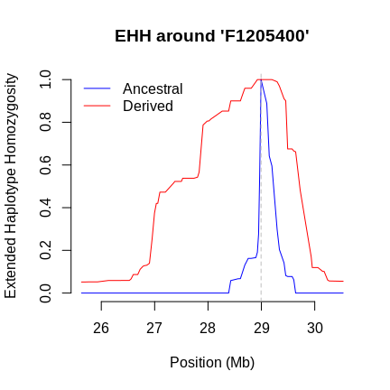

Figure 3.1: Graphical output of the plot.ehh() function

```r
plot(res)
```

For comparison, we might ignore that haplotypes have been phased and set the option `phased` to `FALSE`. Figure 3.2 shows that for this particular marker the differences are rather small:

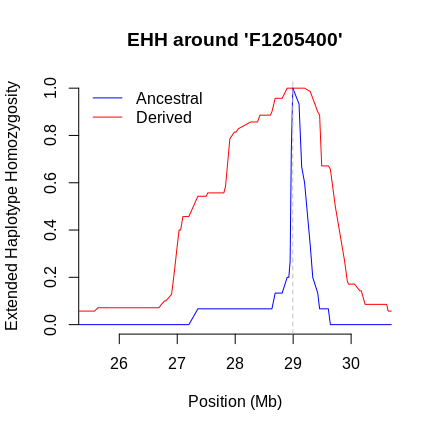

Figure 3.2: Graphical output of the plot.ehh() function

```r
plot(calc_ehh(haplohh_cgu_bta12,
              mrk = "F1205400",
              phased = FALSE),
     xlim = c(2.55E7, 3.05E7))
```

## 3.3 The function `calc_ehhs()`

The `calc_ehhs()` function computes *EHHS* and normalized *EHHS* around the focal marker $s$ relative to another marker $t$. This function also computes the corresponding integrals *iES* and *inES* respectively. The options are identical to those of the function `calc_ehh` (see previous section), except that `polarized` is absent, because variant ancestry status does not figure in the formulas. Details are available by the command:

```r
?calc_ehhs
```

In the following example, the *EHHS* statistics are computed around the SNP `F1205400`.

```r
data(haplohh_cgu_bta12)
res <- calc_ehhs(haplohh_cgu_bta12,
                 mrk = "F1205400",
                 include_nhaplo = TRUE)
```

The output is similar to that of `calc_ehh()`, except that there are no alleles to be distinguished, but instead the wether *EHHS* is normalized or not. A list with four elements is obtained:

1. `mrk.name`: the name/identifier of the focal marker.
2. `ehhs`: a data frame with *EHHS* and *nEHHS* values along the chromosome around the focal marker. Optionally, the column `NHAPLO` can be included to show how many chromosomes were evaluated at each marker.
3. `IES`: *iES*, i.e. the integral over the EHHS curve.
4. `INES`: *inES*, i.e. the integral over the nEHHS curve.

```r
res$mrk.name
```

```
> [1] "F1205400"
```

```r
res$ehhs
```

```
>          POSITION       EHHS      NEHHS NHAPLO
> F1204840 26132031 0.00000000 0.05132310    280
> F1204850 26189286 0.00000000 0.05132310    280
> F1204870 26255986 0.00000000 0.05132310    280
> F1204880 26313792 0.00000000 0.05136758    280
> F1204900 26479781 0.00000000 0.05167890    280
> F1204910 26507987 0.00000000 0.05167890    280
> F1204920 26526646 0.00000000 0.05167890    280
> F1204930 26558947 0.00000000 0.05777185    280
> F1204940 26599290 0.00000000 0.07480543    280
> F1204950 26683271 0.00000000 0.07480543    280
> F1204960 26727974 0.05499232 0.09553035    280
> F1204970 26779948 0.06190476 0.10753836    280
> F1204980 26800201 0.06318484 0.10976206    280
> F1204990 26854850 0.06464414 0.11229709    280
> F1205000 26902773 0.06899642 0.11985768    280
> F1205010 26952729 0.12450077 0.21627752    280
> F1205020 26997449 0.18312852 0.31812319    280
> F1205030 27031612 0.20486431 0.35588170    280
> F1205040 27058533 0.20509473 0.35628197    280
> F1205050 27097980 0.23049155 0.40040027    280
> F1205070 27200291 0.23049155 0.40040027    280
> F1205080 27356111 0.25163850 0.43713587    280
> F1205090 27378189 0.25517153 0.44327329    280
> F1205100 27465862 0.25517153 0.44327329    280
> F1205110 27501592 0.25519713 0.44331777    280
> F1205120 27525360 0.26231439 0.45568157    280
> F1205130 27588853 0.26233999 0.45572604    280
> F1205150 27735666 0.26233999 0.45572604    280
> F1205160 27804138 0.26490015 0.46017345    280
> F1205170 27833642 0.27667691 0.48063153    280
> F1205180 27907564 0.38374296 0.66662219    280
> F1205190 27985596 0.39272913 0.68223260    280
> F1205200 28014498 0.39298515 0.68267734    280
> F1205210 28054852 0.39782386 0.69108294    280
> F1205230 28266218 0.41610343 0.72283745    280
> F1205240 28296968 0.41610343 0.72283745    280
> F1205250 28386447 0.41610343 0.72283745    280
> F1205260 28426219 0.44129544 0.76659996    280
> F1205270 28562210 0.44206349 0.76793418    280
```

[output cut: 19 more lines]

```
> F1205500 29492629 0.33402458 0.58025350    280
> F1205530 29576146 0.33402458 0.58025350    280
> F1205540 29607285 0.32793139 0.56966867    280
> F1205550 29642190 0.32501280 0.56459862    280
> F1205560 29727300 0.23663594 0.41107405    280
> F1205570 29885809 0.12012289 0.20867245    280
> F1205580 29933214 0.08553507 0.14858795    280
> F1205590 29953532 0.06075269 0.10553702    280
> F1205600 30060316 0.06075269 0.10553702    280
> F1205610 30148780 0.05192012 0.09019346    280
> F1205620 30176268 0.05192012 0.09019346    280
> F1205640 30241555 0.00000000 0.05532577    280
> F1205650 30270049 0.00000000 0.05154547    280
> F1205660 30472702 0.00000000 0.05012230    280
> F1205680 30532042 0.00000000 0.05012230    280
```

```r
res$IES
```

```
> [1] 936407.6
```

```r
res$INES
```

```
> [1] 1760565
```

Figure 3.3 can be obtained by setting the output of `calc_ehhs` into the function `plot.ehhs()`:

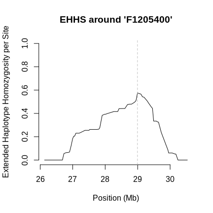

Figure 3.3: Graphical output of the plot.ehhs() function

```r
plot(res)
```

By default, the un-normalized *EHHS* values are plotted. This can be toggled by setting `nehhs = TRUE`. As can be seen in Figure 3.4, the values are scaled to yield 1 at the focal marker.

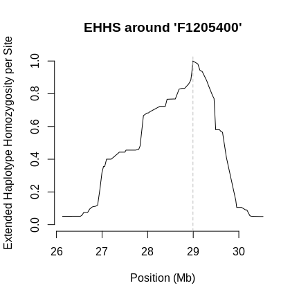

Figure 3.4: Graphical output of the plot.ehhs() function

```r
plot(res, nehhs = TRUE)
```

The parameter `phased` of the function `calc_ehhs()` can be toggled to `FALSE` yielding Figure 3.5. As described above, for unphased data the *EHHS* values are always normalized. For this particular marker we get a similar picture as for phased *nEHHS*.

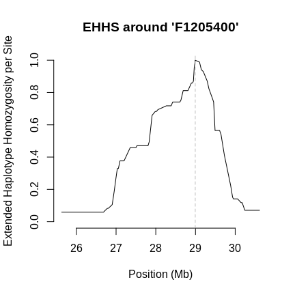

Figure 3.5: Graphical output of the plot.ehhs() function

```r
plot(calc_ehhs(haplohh_cgu_bta12,
               mrk = "F1205400",
               phased = FALSE))
```

## 3.4 The function `scan_hh()`

While the functions `calc_ehh()` and `calc_ehhs()` return the integrated statistics *iHH* and *iES* for a particular marker, the function `scan_hh()` calculates these values for all markers in the `haplohh` object. However, in contrast to `calc_ehh()` which computes an *iHH* value for each allele of a possibly multi-allelic focal marker, `scan_hh()` calculates only two *iHH* values, namely (by default) for the ancestral allele and the derived allele with highest frequency. In case of unpolarized markers (see section 7.6), the option `polarized` should be set to `FALSE`, causing the function to use major and minor (most frequent and second most frequent) alleles instead.

```r
?scan_hh
```

As an example, in order to scan the `haplohh_cgu_bta12` object (containing data on 1424 SNPs for 280 haplotypes), one may use the following command:

```r
data(haplohh_cgu_bta12)
scan <- scan_hh(haplohh_cgu_bta12)
```

The resulting object `scan` is a data frame with 1424 rows (the number of markers declared in the `haplohh` object) and 10 columns:

1. chromosome name
2. position in the chromosome
3. sample frequency of the ancestral / major allele
4. sample frequency of the second-most frequent remaining allele
5. number of evaluated haplotypes at the focal marker for the ancestral / major allele
6. number of evaluated haplotypes at the focal marker for the second-most frequent remaining allele
7. *iHH* of the ancestral / major allele
8. *iHH* of the second-most frequent remaining allele
9. *iES*
10. *inES*

Note that while for phased data the number of evaluated haplotypes of a core allele corresponds to its frequency in the sample, in case of unphased data the evaluation is restricted to haplotypes of homozygous individuals.

The following command prints a chunk of the scan containing the marker `F1205400`:

```r
scan[453:459,]
```

```
>          CHR POSITION     FREQ_A    FREQ_D NHAPLO_A NHAPLO_D     IHH_A
> F1205370  12 28925117 0.06071429 0.9392857       17      263  765720.1
> F1205380  12 28947722 0.82500000 0.1750000      231       49 1477031.7
> F1205390  12 28967990 0.90000000 0.1000000      252       28 1211909.5
> F1205400  12 28993983 0.30357143 0.6964286       85      195  284429.9
> F1205420  12 29101326 0.01785714 0.9821429        5      275  269322.2
> F1205440  12 29147373 0.05714286 0.9428571       16      264  336600.7
> F1205450  12 29197279 0.04285714 0.9571429       12      268  528732.6
>              IHH_D       IES    INES
> F1205370 1121814.8  971728.6 1119699
> F1205380  454891.9  966416.3 1433143
> F1205390  574301.6  954903.3 1204234
> F1205400 2057107.4  936407.6 1760565
> F1205420 1086530.3 1041943.5 1086279
> F1205440 1185898.6 1036274.2 1182946
> F1205450 1149951.0 1039850.3 1148696
```

Note that `scan_hh()` is more efficient than `calc_ehh()` and `calc_ehhs()` applied consecutively for each marker as can be seen by running the two code snippets below:

```r
# perform scan using scan_hh
system.time(scan <- scan_hh(haplohh_cgu_bta12))
```

```
>    user  system elapsed
>   0.345   0.000   0.344
```

```r
# perform scan applying calc_ehh and calc_ehhs to each marker
slow_scan_hh <- function(haplohh) {
  # create empty vectors of size nmrk
  IHH_A <- IHH_D <- IES <- INES <- vector("numeric", nmrk(haplohh))
  # invoke calc_ehh and calc_ehhs for each marker
  for (i in 1:nmrk(haplohh)) {
    res <- calc_ehh(haplohh, mrk = i)
    IHH_A[i] <- res$ihh["IHH_A"]
    IHH_D[i] <- res$ihh["IHH_D"]
    res <- calc_ehhs(haplohh, mrk = i)
    IES[i] <- res$IES
    INES[i] <- res$INES
  }
  # create data frame (the return value of this function)
  data.frame(IHH_A = IHH_A,
             IHH_D = IHH_D,
             IES = IES,
             INES = INES)
}
system.time(slow_scan <- slow_scan_hh(haplohh_cgu_bta12))
```

```
>    user  system elapsed
>   5.169   0.000   5.172
```

Comparing columns shows that the computed values are identical:

```r
identical(slow_scan[, "IHH_A"], scan[, "IHH_A"])
```

```
> [1] TRUE
```

```r
identical(slow_scan[, "IHH_D"], scan[, "IHH_D"])
```

```
> [1] TRUE
```

```r
identical(slow_scan[, "IES"], scan[, "IES"])
```

```
> [1] TRUE
```

```r
identical(slow_scan[, "INES"], scan[, "INES"])
```

```
> [1] TRUE
```

# 4 Computing *iHS*, *Rsb* and *XP-EHH*

## 4.1 The *iHS* within-population statistic

### 4.1.1 Definition

The abbreviation *iHS* refers to “integrated haplotype homozygosity score”. Let *uniHS* represent the un-standardized log-ratio of ancestral *iHH*$^A$ to derived *iHH*$^D$ of a certain focal marker $s$:
$$\mathrm{uniHS}(s)=\ln\left(\frac{\mathrm{iHH}^A(s)}{\mathrm{iHH}^D(s)}\right)$$
Following (Voight *et al.* 2006) we perform a standardization by setting:
$$\mathrm{iHS}(s)=\frac{\mathrm{uniHS}(s) - \mathrm{mean}(\mathrm{uniHS}|p_s)}{\mathrm{sd}(\mathrm{uniHS}|p_s)}$$
where $\mathrm{mean}(\mathrm{uniHS}|p_s)$ and $\mathrm{sd}(\mathrm{uniHS}|p_s)$ represent the mean and standard deviation of *uniHS* restricted to those markers with a similar derived allele frequency as observed at the focal marker ($p_s$). In practice, the markers are binned so that each bin contains not a single frequency but a small range of frequencies to yield enough markers for reliable estimates of mean and standard deviation.

*iHS* is constructed to have an approximately standard Gaussian distribution and to be comparable across markers regardless of their underlying allele frequencies.

For a practical characterization of “outliers” we stretch statistical notation and associate a p-value to *iHS* (Gautier and Naves 2011) by:
$$p_\mathrm{iHS}=-\log_{10}\left(2\Phi\left(-|\mathrm{iHS}|\right)\right)$$
where $\Phi\left(x\right)$ represents the Gaussian cumulative distribution function.

Assuming most of genotyped markers behave neutrally and the distribution of *iHS* values for neutral markers follows indeed a standard Gaussian distribution, we might interpret $p_\text{iHS}$ as a two-sided p-value (on a $-\log_{10}$ scale) of a test on the null hypothesis of no selection.

Alternatively, a one-sided p-value (in a $-\log_{10}$ scale) might be defined (Gautier and Naves 2011) as:
$$\begin{equation*}
p^\text{left}_\text{iHS}=-\log_{10}\left(\Phi\left(\text{iHS}\right)\right)
\end{equation*}$$
allowing the identification of those sites where the derived allele displays a significantly higher extended haplotype homozygosity than the ancestral allele or
$$\begin{equation*}
p^\text{right}_\text{iHS}=-\log_{10}\left(1-\Phi\left(\text{iHS}\right)\right)
\end{equation*}$$
for the opposite case.

Note that this procedure is controversial, because we identify the empirical distribution with the distribution under the null hypothesis of neutrality. This is an approximation at best and only warranted when it can be assumed that there are so few selected sites that their influence on the overall shape of the distribution can be neglected.

In case of unpolarized alleles, the *uniHS* is taken as the ratio of *iHH* from minor to major allele. Since derived allele frequency cannot be accounted for, no binning should be performed. The resulting standardized *iHS* cannot be expected to follow a normal distribution and p-values as defined above are not meaningful.

### 4.1.2 The function `ihh2ihs()`

The `ihh2ihs()` function computes *iHS* using a data frame containing the *iHH* values for ancestral and derived (resp. major and minor) alleles as obtained by the `scan_hh()` function (see section 3.4). The argument `min_maf` allows to exclude focal markers according to their minor allele frequency (by default `min_maf`=0.05). The argument `freqbin` controls the size (or number) of the allele frequency bins used to perform standardization (see section 4.1.1). More precisely, allele frequency bins are built from `min_maf` to 1-`min_maf` in steps of size `freqbin` (by default `freqbin`=0.025). If an integer of 1 or greater is specified, a corresponding number of equally spaced bins is created. If `freqbin` is set to 0, standardization is performed considering each observed frequency as a discrete frequency class, which is useful when there are only a few distinct haplotypes.

For unphased data, *iHH* is calculated using only haplotypes of individuals which are homozygous at the focal marker. This number can be considerably lower than the absolute allele frequency. Hence, in addition to `min_maf`, the option `min_nhaplo` (default `NA`) should be used to reduce statistical noise arising from too few evaluated haplotypes.

Optionally, the allele frequencies of the input data frame can be included into the output by setting `include_freq` to `TRUE`.

A p-value is calculated for standardized *iHS* values. By default, it is two-sided, but a side can be chosen by setting argument `p.side` to `"left"` or `"right"`.

As a typical workflow for performing a whole genome scan one might run `scan_hh()` on haplotype data from each chromosome and concatenate the resulting data frames before standardization. In the following example, we assume that the haplotype files are named as `hap_chr_i.cgu` with $i=1,...,29$ and the marker information file is named `map.inp`. The data frame `wgscan` contains the $iHH^A$ and $iHH^D$ values for the whole genome and serves as input for the `ihh$ihs()` function which calculates *iHS*, i.e. the standardized log ratio of the two $iHH$ values, for each marker.

```r
## demo code - no data files for all chromosomes provided
for(i in 1:29) {
  # haplotype file name for each chromosome
  hap_file = paste("hap_chr_", i, ".cgu", sep = "")
  # create internal representation
  hh <- data2haplohh(hap_file = hap_file,
                     map_file = "map.inp",
                     chr.name = i,
                     allele_coding = "map")
  # perform scan on a single chromosome (calculate iHH values)
  scan <- scan_hh(hh)
  # concatenate chromosome-wise data frames to
  # a data frame for the whole genome
  # (more efficient ways certainly exist...)
  if (i == 1) {
    wgscan <- scan
  } else {
    wgscan <- rbind(wgscan, scan)
  }
}
# calculate genome-wide iHS values
wgscan.ihs <- ihh2ihs(wgscan)
```

For illustration, the object `wgscan.cgu` contains the calculated and concatenated $iHH$ values of a whole genome scan on population CGU (Gautier and Naves 2011):

```r
library(rehh.data)
data(wgscan.cgu)
wgscan.ihs.cgu <- ihh2ihs(wgscan.cgu)
```

```
> Discard focal markers with Minor Allele Frequency equal to or below 0.05 .
> 6890 markers discarded.
> 37167 markers remaining.
```

The resulting object `wgscan.ihs.cgu` is a list with two elements:

1. `ihs`: a data frame with *iHS* and corresponding p-value $p_\mathrm{iHS}$ (p-value in a $-\log_{10}$ scale assuming the *iHS* are normally distributed under the neutral hypothesis). The first rows are displayed below:

```r
head(wgscan.ihs.cgu$ihs)
```

```
>          CHR POSITION        IHS LOGPVALUE
> F0100190   1   113642 -0.5582992 0.2390952
> F0100220   1   244699  0.2723337 0.1049282
> F0100250   1   369419  0.4810736 0.2003396
> F0100270   1   447278  1.0618710 0.5401640
> F0100280   1   487654  0.8184060 0.3839181
> F0100290   1   524507 -0.3897024 0.1569189
```

2. `frequency.class`: a data frame summarizing the derived allele frequency bins used for standardization and mean and standard deviation of the un-standardized values. The first rows are shown below:

```r
head(wgscan.ihs.cgu$frequency.class)
```

```
>              N_MRK MEAN_UNIHS  SD_UNIHS  LOWER_QT  UPPER_QT
> [0.05,0.075)  1090 -0.7117920 0.6106032 -2.030274 0.2952986
> [0.075,0.1)    907 -0.5788939 0.5703576 -1.833828 0.3448781
> [0.1,0.125)    787 -0.4572926 0.4875843 -1.563436 0.3611656
> [0.125,0.15)   837 -0.3992265 0.4542230 -1.403821 0.3629034
> [0.15,0.175)   824 -0.3484786 0.4341126 -1.253109 0.4850874
> [0.175,0.2)    886 -0.2808167 0.4621221 -1.297452 0.5788857
```

## 4.2 The *Rsb* pairwise population statistic

### 4.2.1 Definition

The abbreviation *Rsb* stands for “**r**atio of EHH**S** **b**etween populations”. For a given marker $s$, let
$$\mathrm{unRsb}(s)=\ln\left(\frac{\mathrm{inES}_\text{pop1}(s)}{\mathrm{inES}_\text{pop2}(s)}\right)$$
represent the log-ratio of the *inES* values computed in two populations $pop1$ and $pop2$ (see section 3.1.4). The *Rsb* for marker $s$ is defined as the standardized *unRsb* (Tang *et al.* 2007):

$$\begin{equation*}
\mathrm{Rsb(s)}=\frac{\mathrm{unRsb}(s) - \text{median}({\mathrm{unRsb}})}{\mathrm {sd}({\mathrm{unRsb})}}
\end{equation*}$$
where $\text{median}(\mathrm{unRsb})$ and $\mathrm{sd}(\mathrm{unRsb})$ represent the median and standard deviation of *unRsb* computed over all analyzed markers. Note that for the sake of uniformity, we included the logarithm into the definition of the quantity while in the original article it remained outside. However, we follow (Tang *et al.* 2007) in using the median instead of the mean (hence unlike the definitions of *iHS* and *XP-EHH*). The authors argue that this might increase the robustness against different demographic scenarios.

Like *XP-EHH*, but unlike $iHS$, no binning with respect to allele frequencies is performed (see section 7.6).

As *iHS* (see section 4.1.1), *Rsb* is constructed to have an approximately standard Gaussian distribution and may be transformed analogously into a p-value $p_\text{Rsb}$ (in a $-\log_{10}$ scale), either two-sided or one-sided. As for the latter, $p^\text{left}_\text{Rsb}$ identifies strong extended homozygosity in population $pop2$ relative to population $pop1$ and vice versa for $p^\text{right}_\text{Rsb}$.

### 4.2.2 The function `ines2rsb()`

The `ines2rsb()` function computes *Rsb* using two data frames containing each the *inES* statistics of one population as obtained by the `scan_hh()` function (see section 3.4).

As with *iHS* the *inES* values have to be calculated chromosome-wise and concatenated afterwords (for each population separately) like in the example of section 4.1.2. The *Rsb* values are computed for all markers present in both data frames. They are identified by chromosome name and position, not their identifiers, thus within each population the chromosomal positions must be unique.

Optionally, the allele frequencies of both populations can be taken over from the input data frames (if present there) to the output data frame by setting `include_freq` to `TRUE`.

For illustration, we take calculated and concatenated $inES$ values from a genome scan (Gautier and Naves 2011) provided as example data and compute for each SNP the *Rsb* between the CGU and EUT populations:

```r
data(wgscan.cgu) ; data(wgscan.eut)
## results from a genome scan (44,057 SNPs) see ?wgscan.eut and ?wgscan.cgu for details
rsb.cgu_eut <- ines2rsb(scan_pop1 = wgscan.cgu,
                        scan_pop2 = wgscan.eut,
                        popname1 = "CGU",
                        popname2 = "EUT")
```

```
> Scan of pop1 contains 44057 markers.
> Scan of pop2 contains 44057 markers.
> Merged data contains 44057 markers.
```

The resulting object `rsb.cgu_eut` is a data frame which shows for each marker its *Rsb* and associated p-value. The latter are by default two-sided, but a side can be chosen by setting argument `p.side` to `"left"` or `"right"`. The first rows of the resulting data frame are printed below:

```r
head(rsb.cgu_eut)
```

```
>          CHR POSITION RSB_CGU_EUT  LOGPVALUE
> F0100190   1   113642  -0.3398574 0.13432529
> F0100220   1   244699  -1.0566283 0.53658299
> F0100250   1   369419  -0.1468326 0.05390941
> F0100270   1   447278  -1.8191608 1.16186336
> F0100280   1   487654  -0.2193069 0.08280392
> F0100290   1   524507  -0.7941300 0.36945032
```

## 4.3 The *XP-EHH* pairwise population statistic

### 4.3.1 Definition

The *XP-EHH* (cross-population EHH) statistic (Sabeti *et al.* 2007) is similar to *Rsb* except that it is based on *iES* instead of *inES* (see section 3.1.4). Hence, for or a given marker $s$, let
$$\text{unXP-EHH}(s)=\ln\left(\frac{\mathrm{iES}_\text{pop1}(s)}{\mathrm{iES}_\text{pop2}(s)}\right)$$
represent the log-ratio of the *iES* values computed by the function `scan_hh()` in the populations $pop1$ and $pop2$ (see section 3.1.4).

The *XP-EHH* for a given focal marker is defined as the standardized *unXP-EHH* (Sabeti *et al.* 2007):

$$\begin{equation*}
\text{XP-EHH}(s)=\frac{\text{unXP-EHH}(s) - \text{mean}(\text{unXP-EHH})}{\text{sd}(\text{unXP-EHH})}
\end{equation*}$$
where $\text{mean}(\text{unXP-EHH})$ and $\text{sd}(\text{unXP-EHH})$ represent the mean and standard deviation of *unXP-EHH* computed over all analyzed markers.

As with *Rsb*, the information about the ancestral and derived status of alleles at the focal marker does not figure in the formula and no binning is performed.

As with the previous two scores *iHS* (section 4.1.1) and *Rsb* (section 4.2.1), *XP-EHH* is constructed to have an approximately standard Gaussian distribution and may be transformed analogously into a p-value $p_\text{XP-EHH}$ (in a $-\log_{10}$ scale), either two-sided or one-sided. Among the latter, $p^\text{left}_\text{XP-EHH}$ identifies strong extended homozygosity in population $pop2$ relative to population $pop1$ and vice versa for $p^\text{right}_\text{XP-EHH}$.

### 4.3.2 The function `ies2xpehh()`

The `ies2xpehh()` function computes *XP-EHH* using two data frames, one for each population, containing the *iES* statistics as obtained by the `scan_hh()` function (see section 3.4).

As with *iHS* and *Rsb*, the *iES* have to be calculated chromosome-wise and concatenated afterwords (for each population separately) as has been shown in section 4.1.2. The *XP-EHH* values are computed for all markers present in both data frames. They are identified by chromosome name and position, not their identifiers, thus within each population the chromosomal positions must be unique.

Optionally, the allele frequencies in both populations can be taken over from the input data frames (if present there) to the output data frame by setting `include_freq` to `TRUE`.

For illustration, we take calculated and concatenated $iES$ values from a genome scan (Gautier and Naves 2011) and compute for each SNP the *XP-EHH* between the CGU and EUT populations:

```r
data(wgscan.cgu) ; data(wgscan.eut)
## results from a genome scan (44,057 SNPs) see ?wgscan.eut and ?wgscan.cgu for details
xpehh.cgu_eut <- ies2xpehh(scan_pop1 =  wgscan.cgu,
                           scan_pop2 =  wgscan.eut,
                           popname1 = "CGU",
                           popname2 = "EUT")
```

```
> Scan of pop1 contains 44057 markers.
> Scan of pop2 contains 44057 markers.
> Merged data contains 44057 markers.
```

The resulting object `xpehh.cgu_eut` is a data frame containing for each SNP the *XP-EHH* and associated p-value. The latter are by default two-sided, but a side can be chosen by setting argument `p.side` to `"left"` or `"right"`.

The first rows are displayed below:

```r
head(xpehh.cgu_eut)
```

```
>          CHR POSITION XPEHH_CGU_EUT LOGPVALUE
> F0100190   1   113642    -0.5943673 0.2578513
> F0100220   1   244699    -0.7903997 0.3672448
> F0100250   1   369419    -0.9273568 0.4513142
> F0100270   1   447278    -0.3858354 0.1551387
> F0100280   1   487654    -0.9570604 0.4703941
> F0100290   1   524507    -0.7908863 0.3675322
```

## 4.4 Delineating regions with “outliers”: the function `calc_candidate_regions()`

In contrast to neutral evolution, selection tends to produce clusters of markers with outlier values (Tang *et al.* 2007). For this reason, typically not (only) the markers with outlier scores are reported, but intervals with a conspicuous number or percentage of such markers. Although often similar ad-hoc procedures can be found in the literature, their respective parameters vary widely. We offer the function `calc_candidate_regions()` which scans through the genome in (possibly overlapping) sliding windows and identifies those as “candidates” which fulfill three conditions:

- a minimum number of markers (`min_n_mrk`)
- a minimum number of extremal markers (`min_n_extr_mrk`)
- a minimum percentage of extremal markers among the markers (`min_perc_extr_mrk`).

Markers with extreme values are those with a score greater than specified by parameter `threshold`. Apart from the values of the above conditions, the average of all marker scores and the average of extremal scores is reported for each candidate window.

By default, neighboring and overlapping candidate windows are joined together and the associated values recalculated. This can be turned off by setting `join_neighbors` to `FALSE`.

If `window_size` is set to 1, only the set of extremal markers is returned.

B default, the score itself is tested and reported. Toggling `pval` to `TRUE`, uses the associated p-value instead.

```r
cr.cgu <- calc_candidate_regions(wgscan.ihs.cgu,
                                 threshold = 4,
                                 pval = TRUE,
                                 window_size = 1E6,
                                 overlap = 1E5,
                                 min_n_extr_mrk = 2)
cr.cgu
```

```
>   CHR    START      END N_MRK  MEAN_MRK  MAX_MRK N_EXTR_MRK PERC_EXTR_MRK
> 1   1 61300000 63200000    39 0.7998786 4.392531          3          7.69
> 2   4 48200000 50100000    33 1.0550337 5.993989          3          9.09
> 3   5 27500000 29400000    23 2.3879767 6.079756          3         13.04
> 4   5 79500000 81300000    28 0.8225111 6.752500          2          7.14
> 5   7 52100000 53200000    16 1.8344229 5.019538          2         12.50
> 6  12 28000000 29900000    22 2.6578336 6.294289          3         13.64
> 7  18 11600000 13500000    30 1.9630287 6.203345          3         10.00
>   MEAN_EXTR_MRK
> 1      4.332750
> 2      5.593718
> 3      4.779048
> 4      5.409110
> 5      4.705576
> 6      5.276263
> 7      5.026240
```

# 5 Visualization of the statistics

## 5.1 Un-standardized *iHS*: the function `freqbinplot()`

Since mutations and recombinations tend to shorten stretches of homozygosity between chromosomes, an ancestral (older) allele is expected to have lower extended haplotype homozygosity than a derived (younger) allele. Hence the distribution of unstandardized $iHS=\ln(\frac{iHH^A}{iHH^D})$ is biased towards negative values. More importantly, there is a additional dependency on both ancestral and derived allele frequencies (in the bi-allelic case one is determined by the other). This can be seen by setting the output of the function `ihh2ihs` into the function `freqbinplot()` yielding Figure 5.1.

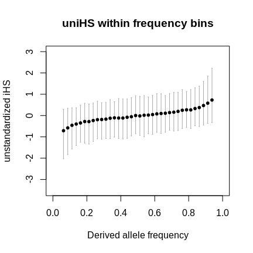

Figure 5.1: Graphical output of the freqbinplot() function

```r
freqbinplot(wgscan.ihs.cgu)
```

Note that this frequency dependence is expected under neutral evolution and not due to selection. In fact, an implicit assumption of the bin-wise standardization is that each bin is dominated by neutral markers. Thus, the bin-wise standardization reduces the dependency of *iHS* on the allele frequency; see section 7.6 of this vignette and Figure 4 in (Voight *et al.* 2006) [In their case the effect is even more pronounced, because they polarized alleles with help of an outgroup *species* while in the case of our data it was done using extant ancestral *populations* as a proxy.]

## 5.2 *Rsb* vs. *XP-EHH* comparison

Figure 5.2 shows a plot of *Rsb* against *XP-EHH* values across the CGU and EUT populations (see section 4.2.2 and 4.3.2 respectively). Marked in red is the marker that was repeatedly used in the examples above. The plot was generated using the following R code:

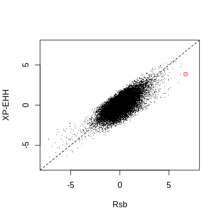

Figure 5.2: Comparison of Rsb and XP-EHH values across the CGU and EUT populations

```r
plot(rsb.cgu_eut[, "RSB_CGU_EUT"],
     xpehh.cgu_eut[, "XPEHH_CGU_EUT"],
     xlab = "Rsb",
     ylab = "XP-EHH",
     pch = ".",
     xlim = c(-7.5, 7.5),
     ylim = c(-7.5, 7.5))
# add red circle for marker with name "F1205400"
points(rsb.cgu_eut["F1205400", "RSB_CGU_EUT"],
       xpehh.cgu_eut["F1205400", "XPEHH_CGU_EUT"],
       col = "red")
# add dashed diagonal
abline(a = 0, b = 1, lty = 2)
```

## 5.3 Distribution of standardized values: the function `distribplot()`

The `distribplot()` function allows to visualize the distributions of the standardized scores (either *iHS*, *Rsb* or *XP-EHH*) and compare them to the standard Gaussian distribution. As an example, in Figure 5.3 the function was applied on the *iHS* estimates obtained for the CGU population (see section 4.1.1):

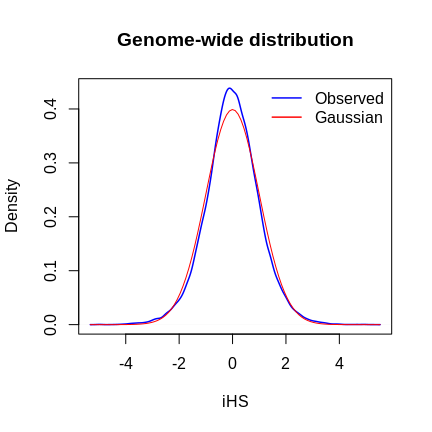

Figure 5.3: Graphical output of the distribplot() function

```r
distribplot(wgscan.ihs.cgu$ihs$IHS, xlab = "iHS")
```

Setting the option `qqplot` to `TRUE` toggles the output to a qqplot, as in Figure 5.4.

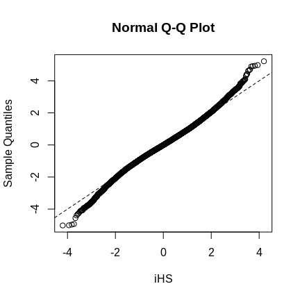

Figure 5.4: Graphical output of the distribplot() function

```r
distribplot(wgscan.ihs.cgu$ihs$IHS,
            xlab = "iHS",
            qqplot = TRUE)
```

## 5.4 Genome wide score plots: the function `manhattanplot()`

The function `manhattanplot()` draws a Manhattan plot of the whole genome scores obtained by the functions `ihh2ihs()`, `ines2rsb()` or `ies2xpehh()`. Figure 5.5 was drawn using the command:

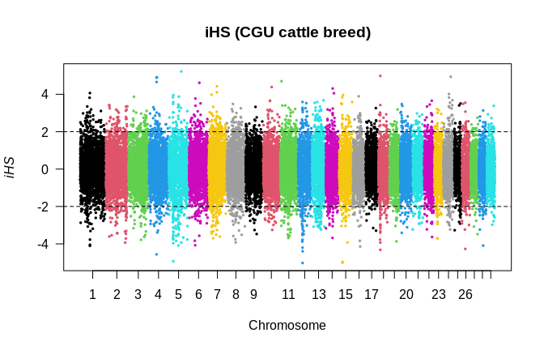

Figure 5.5: Graphical output of the manhattanplot() function

```r
manhattanplot(wgscan.ihs.cgu,
              main = "iHS (CGU cattle breed)")
```

If the option `pval` is switched to `TRUE` the associated p-value instead of the score itself is plotted (Figure 5.6).

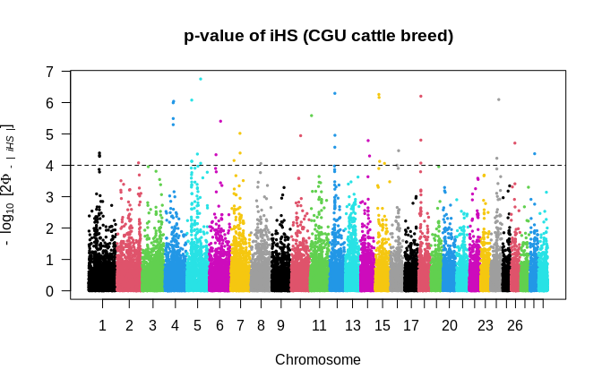

Figure 5.6: Graphical output of the manhattanplot() function

```r
manhattanplot(wgscan.ihs.cgu,
              pval = TRUE,
              threshold = 4,
              main = "p-value of iHS (CGU cattle breed)")
```

The colors of the chromosomes in Figures 5.5 and 5.6 are the default colors of R as obtained by the command `palette()`. It is possible to change them by the same command. Note that the colors are associated with the order of chromosomes in the scan and not their order in the plot.

Candidate regions as obtained by the function `calc_candidate_regions()` can be added to the plot as parameter `cr`. Individual markers can be highlighted by setting argument `mrk` to a vector of marker IDs or a data frame with positions (containing columns with name `CHR` and `POSITION`).

By default, chromosomes are separated by an inset of 5,000,000 bases. This value can be increased by the corresponding parameter in order to further reduce overlap between data points of neighboring chromosomes.

In order to reduce the number of plotted data points, the data set can be rasterized in both dimensions by parameter `resolution`. The data points are then rounded to the specified resolution and duplicate points removed.

Furthermore, it is possible to specify a subset or a re-ordering of chromosomes with help of parameter `chr.name` as in Figure 5.7.

```r
# re-define colors
palette(c("red", "green"))
manhattanplot(wgscan.ihs.cgu,
              pval = TRUE,
              threshold = 4,
              chr.name = c("1", "4", "5", "12"),
              main = "iHS (CGU cattle breed)",
              cr = cr.cgu,
              mrk = "F1205400",
              inset = 1E+7,
              resolution = c(200000, 0.05))
```

```
> Rasterization reduced 6958 data points to 6377 .
```

```r
# set back to default colors
palette("default")
```

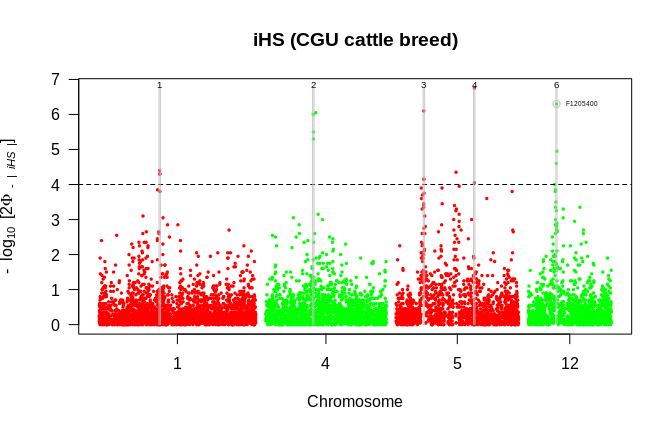

Figure 5.7: Graphical output of the manhattanplot() function

## 5.5 Genome wide score plots: the function `manhattan()` of package `qqman`

The package qqman contains a function `manhattan()` which is similar to the function `manhattanplot()` of this package. The input data frame is expected to have a slightly different format, though. Hence, before plotting we need to “translate” our data as in the following example with *iHS* values:

```r
# extract data frame from result list
ihs <- wgscan.ihs.cgu$ihs
# create new data frame
wgscan.cgu.ihs.qqman <- data.frame(
    CHR = as.integer(factor(ihs$CHR,
                            levels = unique(ihs$CHR))),
                               # chromosomes as integers
    BP = ihs$POSITION,         # base pairs
    P = 10**(-ihs$LOGPVALUE),  # transform back to p-values
    SNP = row.names(ihs)       # SNP names
    )
```

We can now use the new data frame as input for the function `manhattan()` to obtain Figure 5.8:

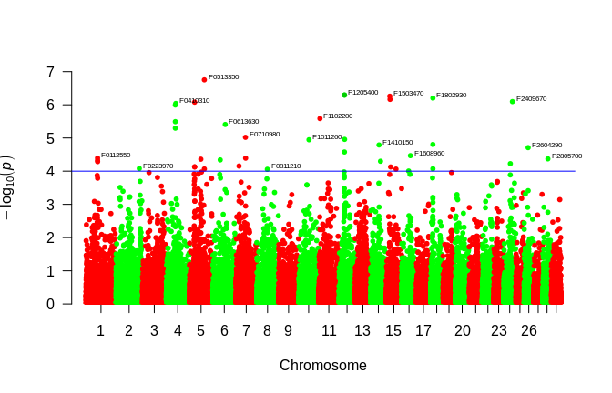

Figure 5.8: Graphical output of the qqman::manhattan() function

```r
library(qqman)
qqman::manhattan(wgscan.cgu.ihs.qqman,
                 col = c("red","green"),
                 chrlabs = unique(ihs$CHR),
                 suggestiveline = 4,
                 highlight = "F1205400",
                 annotatePval = 0.0001)
```

# 6 Visualization of the haplotype structure

## 6.1 The function `plot.haplohh()`

Chunks of the haplotype matrix can be plotted, provided they are not too large, with sequences in rows and markers in columns. The following plot shows a chunk of 200 SNPs in the vicinity of SNP `F1205400` which is identified by the dashed line. The derived alleles are marked in red, the ancestral ones not shown.

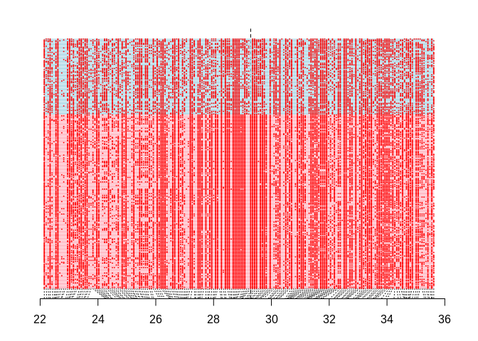

Figure 6.1: Graphical output of the plot.haplohh() function

```r
hh_subset <- subset(haplohh_cgu_bta12, select.mrk = 350:550)
oldpar <- par(mar = c(3, 2, 2, 2) + 0.1)
plot(
  hh_subset,
  mrk = "F1205400",
  group_by_allele = TRUE,
  ignore.distance = TRUE,
  col = c(NA, "red"),
  linecol = c("lightblue", "lightpink"),
  mrk.col = "black",
  cex = 0.1,
  pos.lab.hap = "none",
  pos.lab.mrk = "none"
)
par(oldpar)
```

The sequences are ordered with respect to the alleles of SNP `F1205400`: the lower two thirds of sequences contain the derived allele and are more homogenous around the SNP than the sequences carrying the ancestral allele.

## 6.2 The functions `calc_furcation()` and `plot.furcation()`

Furcation structures portray the decay of haplotype homozygosity around a focal marker (Sabeti *et al.* 2002). They represent the complete information contained in the concept of extended shared haplotypes of which *EHH* and *EHHS* can be regarded as summary statistics. For each allele of a focal marker and each side (“left” or “right”), furcations arise when the extension step reaches a marker whose alleles distinguish hitherto identical haplotypes. In case of bi-allelic markers without missing values these can be only bifurcations. The furcation structure for a specific allele and a specific side is hence a tree with its root at the focal marker. A stark contrast between furcation structures of different core alleles should correspond to outlier values of *iHS*.

The function `calc_furcation()` calculates such a furcation structure around a focal marker.

```r
data(haplohh_cgu_bta12)
furcation <- calc_furcation(haplohh_cgu_bta12,
                            mrk = "F1205400")
```

The result is an object of class `furcation`, comprising a set of tree structures with some additional information, see `?"furcation-class"` for technical details.

The function `plot.furcation()` renders graphically the furcation object. Within the plot, the root (focal marker) is identified by a vertical dashed line. The diagram is bi-directional, portraying decay along both sides of the focal marker. The thickness of the lines corresponds to the number of chromosomes sharing a haplotype.

As an illustration, Figure 6.2 shows the bifurcation diagrams for derived and ancestral allele of the marker `F1205400`.

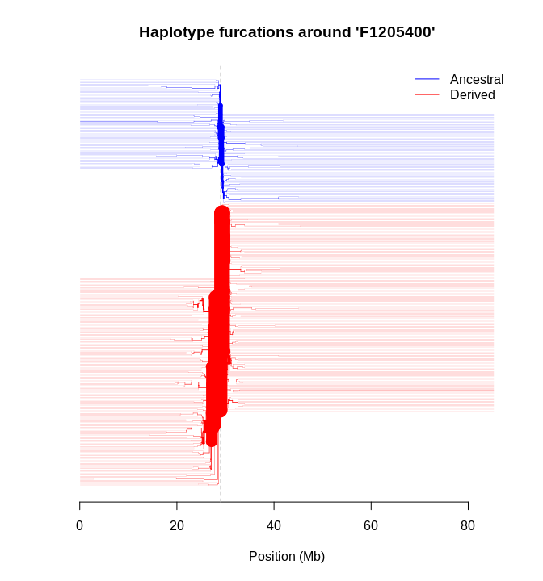

Figure 6.2: Graphical output of the plot.furcation() function

```r
plot(furcation)
```

It is possible to zoom into furcations using parameter `xlim` and label the leaves using the parameter `hap.names`, as shown in Figure 6.3, produced by the following command. Labels in bold indicate that further chromosomes are associated with the corresponding branch.

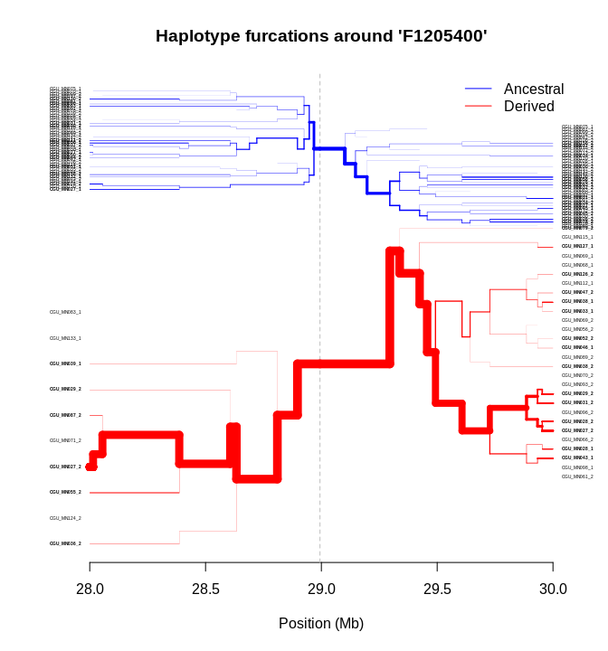

Figure 6.3: Graphical output of the plot.furcation() function

```r
plot(furcation,
     xlim = c(2.8E+7, 3E+7),
     lwd = 0.05,
     hap.names = hap.names(haplohh_cgu_bta12),
     cex.lab = 0.3)
```

Individual trees can be exported into Newick format. The function `as.newick` produces a (possibly very long) string in this format. The following command extracts the furcation tree of the ancestral allele on the left side of the marker:

```r
newick <- as.newick(furcation,
                    allele = 0,
                    side = "left",
                    hap.names = hap.names(haplohh_cgu_bta12))
```

Such a string can be rendered graphically e.g. by the R package ape yielding Figure 6.4:

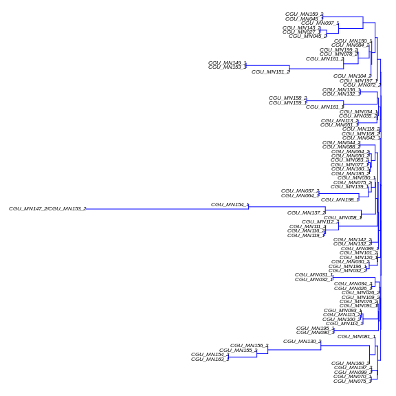

Figure 6.4: Graphical output of the ape::plot.phylo() function

```r
library(ape)
tree <- ape::read.tree(text = newick)
plot(tree,
     cex = 0.5,
     direction = "leftwards",
     edge.color = "blue",
     underscore = TRUE,
     no.margin = TRUE)
```

## 6.3 The functions `calc_haplen()` and `plot.haplen()`

To each haplotype in the sample the length of its longest shared haplotype is assigned, i.e. the range over which it is identical to at least one other haplotype (the latter might be different left and right to the focal marker). It corresponds to the maximal extension of the inner branches to both sides of the focal marker in a furcation diagram. The function `calc_haplen()` calculates this quantity:

```r
haplen <- calc_haplen(furcation)
```

The `haplen` object is a list with four elements:

1. `mrk.name`: the name/identifier of the focal marker
2. `position`: the position of the focal marker
3. `xlim`: the position of first and last marker in the data set
4. `haplen`: a data frame with begin and end positions of the extended shared haplotypes.

```r
haplen$mrk.name
```

```
> [1] "F1205400"
```

```r
haplen$position
```

```
> [1] 28993983
```

```r
haplen$xlim
```

```
> [1]    79823 85277438
```

```r
head(haplen$haplen)
```

```
>   ALLELE DESCRIPTION      MIN      MAX
> 1      0   Ancestral 28054852 29424210
> 2      0   Ancestral 28810078 30241555
> 3      0   Ancestral 23020095 31105214
> 4      1     Derived 25932431 31009388
> 5      1     Derived 24259278 32960675
> 6      1     Derived 26683271 31457115
```

Haplotype length is visualized in Figure 6.5 obtained by the command

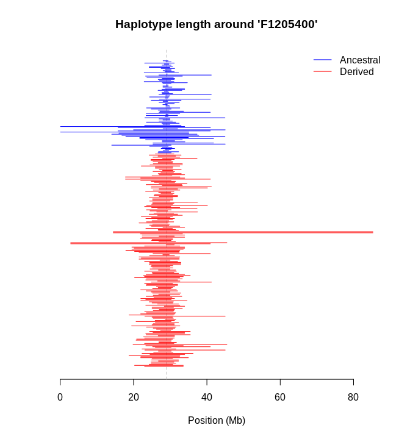

Figure 6.5: Graphical output of the plot.haplen() function

```r
plot(haplen)
```

As with a furcation plot, one can zoom into the picture using the parameter `xlim` and select alleles using parameter `allele`. The following command yields Figure 6.6 showing only the region to the “left” of the focal marker and only the chromosomes of the ancestral core allele.

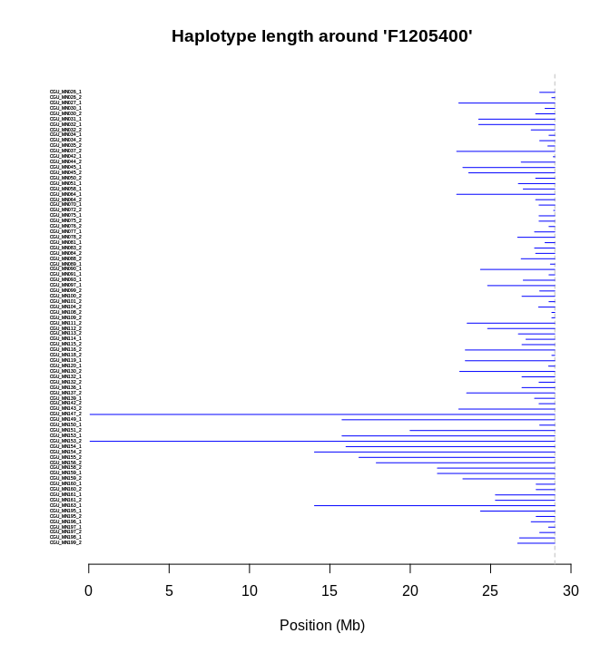

Figure 6.6: Graphical output of the plot.haplen() function

```r
plot(haplen,
     allele = 0,
     xlim = c(haplen$xlim[1], haplen$position),
     hap.names = hap.names(haplohh_cgu_bta12),
     cex.lab = 0.3,
     legend.xy.coords = "none")
```

We give a small example on how to check visual results by directly accessing the data of the `haplohh-class` object (see also its documentation by `?"haplohh-class"`): from Figures 6.4 or 6.6 it appears that two extended shared haplotypes reach the left border and we might identify them by their labels as `CGU_MN147_2` and `CGU_MN153_2`. We can prove that there are indeed exactly two haplotypes in the sample which are identical within the complete region to the “left” of the focal marker:

```r
# finding the index number of marker "F1205400"
mrk.nr = which(mrk.names(haplohh_cgu_bta12) == "F1205400")
# subset of all markers on the "left" of the focal one
hh_left = subset(haplohh_cgu_bta12, select.mrk = 1:mrk.nr)
```

```
> * Subset markers *
> 968 markers discarded.
> 456 markers remaining.
> * Filtering data *
> Discard markers genotyped on less than 100 % of haplotypes.
> No marker discarded.
> Data consists of 280 haplotypes and 456 markers.
> Number of mono-, bi-, multi-allelic markers:
> 1 2
> 6 450
```

```r
# check for duplicated rows
which(duplicated(haplo(hh_left)))
```

```
> CGU_MN153_2
>         248
```

```r
# row 248 is identical to a previous row, but which one?
# get the other row by a search in opposite direction
which(duplicated(haplo(hh_left), fromLast = TRUE))
```

```
> CGU_MN147_2
>         236
```

```r
# extract the corresponding haplotype names
hap.names(hh_left)[c(236, 248)]
```

```
> [1] "CGU_MN147_2" "CGU_MN153_2"
```

Finally, after working through the vignette, we remove the example files from the current working directory:

```r
remove.example.files()
```

# 7 Data considerations

## 7.1 Multi-allelic markers

For many species, a low per-site mutation rate ensures that the vast majority of Single Nucleotide Polymorphisms (SNPs) is observed with only two alleles in a sample. Hence bi-allelic SNPs will constitute the foremost kind of data to apply our package onto. However, we think the ability to calculate the statistics for multi-allelic markers might be useful

- for species and/or genomic regions with a high per-site mutation rate
- for genetic variation in form of (short) tandem repeats or (larger) copy number variations which are multi-allelic by definition and may carry information not captured by SNP markers
- because the relative rarity of multi-allelic SNPs might make these particularly interesting
- since the original approach of (Sabeti *et al.* 2002) did not compare *EHH* on the two *core alleles* of a single SNP, but for multiple *core haplotypes* defined by several neighboring SNPs; such a partition could be created in *rehh* by adding an artificial multi-allelic marker.

## 7.2 Dealing with gaps

Certain genomic regions such as centromeres are difficult to sequence and can give rise to large gaps between consecutive markers. If not accounted for, these will cause spuriously inflated values of the “integrals” *iHH* and *iES*. (Voight *et al.* 2006) applied two corrections for gaps. First, they introduced a penalty proportional to physical distance that resulted in any gap being greater than 20 kb to be re-scaled to this number. Second, they discarded integration, if two consecutive markers with a distance greater than 200 kb were encountered. Both methods are implemented in *rehh*, yet turned off by default, since the corresponding thresholds should be adapted manually to the specific data set.

## 7.3 Dealing with missing data

Most phasing programs (such as *fastPHASE* or *SHAPEIT2*) interpolate (“impute”) missing genotypes, hence at least for phased SNP markers, missing values should be rather the exception than the rule.

In cases where missing values cannot be avoided, there is no generally accepted way of handling them. Some authors replace them probabilistically by the “background” frequency of alleles observed on the remainder chromosomes (i.e. a simple kind of “imputing”). We implemented instead the following approach: every time when the extension of shared haplotypes reaches a new marker, all chromosomes with missing values are removed from further calculations; exempt are chromosomes which at that point do not share any more a haplotype with another chromosome.

The number of chromosomes evaluated at each position is reported in the results of `calc_ehh()` resp. `calc_ehhs()`, if the parameter `include_nhaplo` is set to `TRUE`. If there are missing values, this number will decrease monotonically with increasing distance to the focal marker. Without missing values, the number will be constant until calculation is stopped, e.g. by reaching the boundary condition `limehh(s)`.

Our approach to handle missing values has two non-obvious consequences: first, under certain circumstances, *EHH* or *EHHS* can transiently increase, namely if the removal of chromosomes leads accidentally to a more homogeneous set. Second, the normalization factor for *nEHHS* has to be recalculated based on the reduced set and is no longer constant over the entire region. For realistic data, however, both effects should be negligible.

## 7.4 Dealing with multiple markers at the same position

Errors or typos aside, there are several possibilities how multiple markers with the same chromosomal position can arise:

- If positions are defined by genetic distances, two markers can have zero distance, if no recombination is observed between them.
- The *variant call format* allows to specify different kinds of markers in the same file. Hence at a certain position one might observe a SNP as well as an Insertion/Deletion or a tandem repeat.
- In output of *ms* the positions are given with a pre-set precision and consequently the positions of two different segregating sites might be rounded to the same number.

Since it is unclear how *rehh* should handle such markers, they are not accepted as input. Ideally, multiple markers should be dealt with by a pre-processing of the data outside of the package. As a quick-and-dirty work-around, we offer the option `remove_multiple_markers` in function `data2haplohh()`, which, if set to `TRUE`, removes all but the first marker with identical positions.

## 7.5 Dealing with unphased data

Notwithstanding expensive experimental methods, current high-throughput genotyping / sequencing technologies cannot directly assign alleles to specific chromosomes of a heterozygous diploid (or multiploid) individual. Instead, this task of *phasing* is typically performed by specialized bioinformatic tools like *SHAPEIT* (O’Connell *et al.* 2014) and *fastPHASE* (Scheet and Stephens 2006). Although computationally demanding, the application of these tools is straight-forward and the results usually of sufficient quality for the calculation of *EHH* based statistics. Typically, the tools interpolate missing values away.

In the presumably rare cases where phasing is not feasible, *EHH* or *EHHS* can only be meaningfully estimated by reducing the set of compared chromosomes to those of homozygous (at the focal marker) individuals (assuming that the input data is ordered correspondingly). However, this reduction entails a substantial loss of power; even by an adapted parameter setting (see below) at the very minimum 10, but better up to 30 sequences are needed to obtain at least moderately accurate estimations.

For the within-population statistic *iHS*, the latter requirement concerns both major and minor alleles of a marker and scans should not be performed on samples comprising less than 100 sequences. Even for sample sizes of 200 sequences, meaningful estimation of *iHS* is hence restricted to variants of intermediate frequencies, i.e. high minor frequency.

For the cross-population statistics *Rsb* and *XP-EHH* a minimum number of 30 sequences from homozygous individuals is usually fulfilled if the sample size of each population exceeds 60 sequences. Hence, for unphased sequences the following parameters shoudl be set:

- the option `phased` of the functions `calc_ehh()`, `calc_ehhs()` and `scan_hh()` must be set to `FALSE`. However, if the data is actually phased, this entails a substantial loss of power to detect selection!

A few shared haplotypes of extreme length are usually encountered in neutrally evolving regions. In order to limit this “statistical noise”, cut-off rules are for unphased sequences even more important than they are for phased ones

- the cut-off for the calculation of *EHH* resp. *EHHS* defined by option `limehh` resp. `limehhs` should be increased from the default value of 0.05 to 0.1.
- in function `ihh2ihs()`, hence for a within-population scan using *iHH* values, in addition to the filtering by the MAF of core alleles (parameter `min_maf`, default 0.05), a minimum absolute number of evaluated haplotypes should be set by parameter `min_nhaplo`; this value should never be lower than 10 and, if the sample size allows, be as high as 30.
- if the latter option is set to 20 or lower, a further cut-off, supplementing `limehh`, namely `limhomohaplo` should be set to 4, meaning that calculation of *EHH*/*EHHS* is stopped when less than 4 sequences (two individuals) remain homozygous.

See (Klassmann and Gautier 2020) for a study on estimating *iHS*, *Rsb* and *XP-EHH* using unphased sequences.

## 7.6 Dealing with unpolarized data

The designation of alleles as ‘ancestral’ or ‘derived’ is referred to as *polarization*. Since sequences of ancient genomes are available only for a few species and restricted to a limited time back to the past, the ‘ancestral’ allele is usually inferred to be the one carried by one or more outgroup species such as chimpanzees or gorillas for humans. However, this presupposes the existence of a reference sequence of a suitable ‘neighbor’ species of sufficient quality as well as reliable genome-wide alignments. These requirements are not trivial and even if they are fulfilled, any alignment will not cover the whole genome and the covered part will contain mis-specified alleles due to invisible secondary or back-mutations (Baudry and Depaulis 2003), possibly causing spurious signals of selection (Hernandez *et al.* 2007).

Note that the bin-wise standardization of *iHS* is the only calculation step within our package where the information about ancestry is exploited. The information of ancestry status is valuable since the expected values under neutral evolution depend on the respective allele frequencies at the focal marker (see Figure 5.1 of this vignette and Figure 4 of (Voight *et al.* 2006)). The binning of markers by frequency before its standardization (see section 4.1.2) is aimed to eliminate most of this dependence. For unpolarized alleles this correction cannot be done.

Hence two parameters are important when dealing with unpolarized data:

- since in this case the internal coding of alleles as 0,1,2 etc. conveys no information about ancestral status, it is appropriate to set the parameter `polarized` in function `scan_hh` to `FALSE`: *iHH* values are then computed for the major (most frequent) and minor (second-most frequent) alleles.
- the standardization of *iHS* for such data should NOT be done in a frequency-dependent manner and consequently the parameter `freqbin` in the function `ihh2ihs()` should be set to 1 (one bin).

Simulations have shown that neglecting ancestry status reduces the strength of the signal, yet conspicuous values remain clustered; consequently, a delineation of candidate regions of selection should rely primarily on this latter feature. For a more detailed analysis see (Klassmann and Gautier 2020).

# 8 Differences to the program *hapbin*

The C++ program *hapbin* (Maclean *et al.* 2015) is an alternative tool to calculate the statistics *iHS* and *XP-EHH*. The obtained values vary between *hapbin* and *rehh*. As far as we can tell, this is due to the differences in implementation listed below. The first 4 are hard-wired and cannot be remediated without changing the code while all further discrepancies can be largely eliminated by appropriate parameter settings. We refer to version 1.3.0 of *hapbin*.

1. *Hapbin* disregards the markers directly at the border of chromosomes.
2. If an allele of a focal marker is present only on a single chromosome, *hapbin* assigns a *EHH* value of 1 at the focal marker and zero otherwise. *rehh* assigns zero at the focal marker, too.
3. *Rehh* stops computing *EHH* for each allele separately if a lower threshold set by `limehh` is reached. *Hapbin* continues the calculation until the values for both alleles fall below the threshold (set by `-c` or `--cutoff`).
4. For the standardization of *iHS* resp. *XP-EHH*, *hapbin* uses the estimator $\sqrt{\frac{1}{n}\sum(x_i-\bar{x})^2}$ for the standard deviation while *rehh* uses $\sqrt{\frac{1}{n-1}\sum(x_i-\bar{x})^2}$.
5. The bins used by *hapbin* for the standardization of *iHS* cover the whole interval ]0,1], while in *rehh* they span the interval [`min_maf`,1-`min_maf`[. *Hapbin* includes the upper endpoint into each bin, while *rehh* includes by default the lower endpoint. The latter can be changed by setting the parameter `right` of `ihh2ihs()` to `TRUE`.
6. The default number of bins is 50 in *hapbin*, yielding a bin width of 0.02. The default width in *rehh* is 0.025 (yielding 36 bins, see point above!). Setting the number of bins in *hapbin* to 40 with option `-b` or `--bin` yields a bin width of 0.025.
7. *hapbin* uses by default another estimator for homozygosity than *rehh* (see section 9). If run with option `-a` or `--binom`, it uses the same as *rehh*.
8. Integration over *EHH* resp. *EHHS* is performed by *hapbin* on the area between the curve spanned by these quantities and the x-axis (y=0) while *rehh* by default integrates only over the part of that area that is above the threshold set by the parameters `limehh` resp. `limehhs`, i.e. the area between the curve and the line y=threshold. This is not to be confused with the condition for truncation at left and right ends of the curve which is (for all practical purposes) handled identically by both programs. Setting in *rehh* the parameter `lower_y_bound` to zero makes the integration identical to that of *hapbin*. As mentioned above, `limehh(s)` of *rehh* corresponds to `-c` or `--cutoff` of *hapbin*.
9. By default, the parameter `discard_integration_at_border` is `TRUE` in *rehh*. It has to be set to `FALSE` in order to conform to *hapbin*.
10. Large differences can arise from different handling of gaps during the integration of *EHH* resp. *EHHS* yielding *iHH* resp. *iES*. *Hapbin* has a parameter `-s` or `--scale` to “down-weight” large gaps by capping them to the specified value. Its default value is 20000 while the corresponding option in *rehh* is turned off by default, but can be set by `scalegap`. The option `maxgap` within *rehh* leads to a stop of the integration and if the parameter `discard_integration_at_border` is set to `TRUE`, then no value is reported. This has no counterpart in *hapbin*. Instead, *hapbin* allows to specify a maximum length of Extended Haplotypes (disabled by default) which is available as option of the function `scan_hh_full()` in *rehh*.

# 9 About estimating homozygosity

The term *homozygosity* as component of the abbreviation *EHH* refers to the probability that two arbitrarily chosen chromosomes from a large population are identical at a given locus or in a given region. It does not make any statement about homozygosity of individuals or even presuppose that individuals are diploid. One might even argue, whether the term *homogeneity* would have been more appropriate.

If there are $K$ alleles in the population and each allele has a population frequency of $f_k$, then this probability is given by
$$H=\sum_{k=1}^{K}f_k^2\;.$$
For each allele $k$, its population frequency can be estimated by its sample frequency $x_k$: if the sample contains $n$ chromosomes and allele $k$ is observed $n_k$ times, then
$$\hat{f_k}=\frac{n_k}{n}=x_k\;.$$
It seems straightforward to estimate the population homozygosity from a sample by
$$\hat{H_1}=\sum_{k=1}^Kx_k^2=\sum_{k=1}^K\left(\frac{n_k}{n}\right)^2\;.$$
However, it turns out that this estimator is biased (it yields values that tend to be slightly too high). The following estimator, instead, is unbiased (Nei and Roychoudhury 1974):
$$\hat{H_2}=\frac{n}{n-1}\sum_{k=1}^{K_{s,t}}x_k^2-\frac{1}{n-1}\;.$$
The latter is used by *rehh*. We can see this e.g. in Equation (3.3), when we consider each (shared) haplotype in the region between markers $s$ and $t$ as an allele. We get

$$EHHS=\frac{1}{n(n-1)}\sum_{k=1}^{K_{s,t}}n_k(n_k-1)=\frac{n}{n-1}\frac{1}{n^2}\sum_{k=1}^{K_{s,t}}(n_k^2-n_k)=\frac{n}{n-1}\left(\sum_{k=1}^{K_{s,t}}\frac{n_k^2}{n^2}-\frac{n}{n^2}\right)=\hat{H_2}\;.$$
*hapbin*, in constrast, uses by default estimator $\hat{H_1}$ and refers to $\hat{H_2}$ as the “alternative” estimator. Evidently, for large $n$, the difference between the two becomes negligible. For small $n$ this is not necessarily so. If we consider a minimal sample of two non-identical chromosomes, hence $n=2$ and $K=2$, then we have
$$\hat{H_1}=\left(\frac{1}{2}\right)^2+\left(\frac{1}{2}\right)^2=\frac{1}{2}$$
and
$$\hat{H_2}=\frac{1}{2\cdot 1}(1\cdot 0+1\cdot 0)=0\;.$$
Interestingly, although $\hat{H_1}$ is biased, it yields values which are on average closer to the population value than $\hat{H_2}$, since the variance of $\hat{H_1}$ is smaller than that of $\hat{H_2}$ (Nei and Roychoudhury 1974).

It is unlikely, though, that the choice of the estimator has a major effect on detecting selection.

# References

Baudry E., Depaulis F., 2003 Effect of misoriented sites on neutrality tests with outgroup. Genetics **165**: 1619–1622.

Cadzow M., Boocock J., Nguyen H. T., Wilcox P., Merriman T. R., Black M. A., 2014 A bioinformatics workflow for detecting signatures of selection in genomic data. Frontiers in Genetics **5**: 1–8.

Ewing G., Hermisson J., 2010 MSMS: a coalescent simulation program including recombination, demographic structure and selection at a single locus. Bioinformatics **26**: 2064–5.

Gautier M., Klassmann A., Vitalis R., 2017 rehh 2.0: a reimplementation of the R package rehh to detect positive selection from haplotype structure. Molecular Ecology Resources **17**: 78–90.

Gautier M., Naves M., 2011 Footprints of selection in the ancestral admixture of a new world creole cattle breed. Mol Ecol **20**: 3128–3143.

Haasl R. J., Payseur B. A., 2016 Fifteen years of genomewide scans for selection: Trends, lessons and unaddressed genetic sources of complication. Molecular Ecology **25**: 5–23.

Hellenthal G., Stephens M., 2007 msHOT: Modifying Hudson’s ms simulator to incorporate crossover and gene conversion hotspots. Bioinformatics **23**: 520–521.

Hernandez R. D., Williamson S. H., Bustamante C. D., 2007 Context dependence, ancestral misidentification, and spurious signatures of natural selection. Molecular Biology and Evolution **24**: 1792–800.

Hudson R. R., 2002 Generating samples under a Wright-Fisher neutral model of genetic variation. Bioinformatics **18**: 337–338.

Kelleher J., Etheridge A. M., McVean G., 2016 Efficient coalescent simulation and genealogical analysis for large sample sizes. PLoS Comput Biol **12**: 1–22.

Klassmann A., Gautier M., 2020 Detecting selection using extended haplotype homozygosity-based statistics on unphased or unpolarized data (preprint). https://doi.org/10.22541/au.160405572.29972398/v1.

Maclean C. A., Hong N. P. C., Prendergast J. G. D., 2015 Hapbin: An efficient program for performing haplotype-based scans for positive selection in large genomic datasets. Mol Biol Evol **32**: 3027–3029.

Nei M., Roychoudhury K., 1974 Sampling Variances of Heterozygosity and Genetic Distance. Genetics **76**: 379–390.

O’Connell J., Gurdasani D., Delaneau O., Pirastu N., Ulivi S., others, 2014 A general approach for haplotype phasing across the full spectrum of relatedness. PLoS Genet **10**: e1004234.

Oleksyk T. K., Smith M. W., O’Brien S. J., 2010 Genome-wide scans for footprints of natural selection. Philosophical Transactions of the Royal Society B: Biological Sciences **365**: 185–205.

Sabeti P. C., 2006 Positive natural selection in the human lineage. Science **312**: 1614–1620.

Sabeti P. C., Reich D. E., Higgins J. M., Levine H. Z. P., Richter D. J., others, 2002 Detecting recent positive selection in the human genome from haplotype structure. Nature **419**: 832–837.

Sabeti P. C., Varilly P., Fry B., Lohmueller J., Hostetter E., others, 2007 Genome-wide detection and characterization of positive selection in human populations. Nature **449**: 913–918.

Scheet P., Stephens M., 2006 A fast and flexible statistical model for large-scale population genotype data: Applications to inferring missing genotypes and haplotypic phase. Am J Hum Genet **78**: 629–644.

Tang K., Thornton K. R., Stoneking M., 2007 A new approach for using genome scans to detect recent positive selection in the human genome. PLoS Biol **5**: e171.

Utsunomiya Y. T., Pérez O’Brien A. M. P., Sonstegard T. S., Sölkner J., Garcia J. F., 2015 Genomic data as the "hitchhiker’s guide" to cattle adaptation: Tracking the milestones of past selection in the bovine genome. Frontiers in Genetics **5**: 1–13.

Vitti J. J., Grossman S. R., Sabeti P. C., 2013 Detecting natural selection in genomic data. Annual Review of Genetics **47**: 97–120.

Voight B. F., Kudaravalli S., Wen X., Pritchard J. K., 2006 A map of recent positive selection in the human genome. PLoS Biol **4**: e72.

Weigand H., Leese F., 2018 Detecting signatures of positive selection in non-model species using genomic data. Zoological Journal of the Linnean Society **184**: 528–583.